# Pregnant Female Data Analysis Colorado 2022

Robin Bedard & Savannah Weaver

# Packages

```r
library("tidyverse") # for dplyr workflow + ggplot
library("rmdformats") # pretty Rmd format
library("lme4") # LMM
library("lmerTest") # LMM stats
library("car") # vif, anova
library("emmeans") # pairwise comparisons
library("broom") # clean stats presentation
library("AICcmodavg") # model selection
library("MuMIn") # GLMM R-squared
library("effects") # partial regression plots
library("ggpubr") # figure arranging & exporting
```

# Figure Formatting

```r
my_ggplot_theme <- theme_classic() + # start with a preset theme to make things easy
                     theme(axis.title = element_text(size = 10), # text size for axis labels
                           axis.text = element_text(size = 8, # text size for axis values
                                                    color = "black", # need to specifically set color
                                                    family = "sans"), # and family
                           legend.title = element_text(size = 8), # text size for the legend title
                           legend.text = element_text(size = 8), # text size for legend items
                           text = element_text(color = "black", # color for all text (except axis values)
                                               family = "sans") # family
                           )
```

Now, apply the theme. This sets the theme for the entire Rmd document.

```r
theme_set(my_ggplot_theme)
```

# Load & Tidy Data

## CEWL, Osml, Mass, SVL

```r
mother_data_all <- read_rds("data/mother_data_all.RDS")
```

## Birthing Timeline

This dataframe includes a column “Day Relative” which is the number of days, relative to the day they gave birth, that the measurements were taken.

```r
day_scale <- read_csv("data/day_relative_to_birth.csv")

day_scale_clean <- day_scale %>%
  mutate(IndivID = as.factor(str_trim(IndivID)),
         CEWLBloodCollectDate = as.Date(str_trim(CEWLBloodCollectDate),
                                         format = "%m/%d/%y"),
         DayRelativeToZero = as.numeric(DayRelativeToZero)
  ) %>%
  #rename all column names
  dplyr::select(Indiv_ID = IndivID,
                CEWL_Blood_Collect_Date = CEWLBloodCollectDate,
                Day_Relative = DayRelativeToZero) %>%
  fill(Indiv_ID)
```

## Tmt Timeline

First, uploading the CSV with the new column of days relative to number of days in hydration treatment.

```r
days_in_tmt <- read_csv("data/days_in_tmt.csv")

days_in_tmt_clean <- days_in_tmt %>%
  mutate(IndivID = as.factor(str_trim(IndivID)),
         CEWLBloodCollectDate = as.Date(str_trim(CEWLBloodCollectDate),
                                         format = "%m/%d/%y"),
         DaysInTrmt = as.numeric(DaysInTrmt),
         GaveBirth = as.factor(GaveBirth)
  ) %>%
  #rename all column names
  dplyr::select(Indiv_ID = IndivID,
                CEWL_Blood_Collect_Date = CEWLBloodCollectDate,
                Days_in_Treatment = DaysInTrmt,
                Gave_Birth = GaveBirth)  %>%
  fill(Indiv_ID)
```

## Offspring

```r
neo_counts <- read_csv("data/neonate_count.csv",
                       col_types = "fddd") %>%
  mutate(
    total_embryos = (live_neonates+dead_at_birth+slugs),
    prop_live = live_neonates/total_embryos
  )
```

## Merge Dataframes

```r
mother_data_all_final_full <- mother_data_all %>%
  left_join(day_scale_clean,
            by = c("Indiv_ID", "CEWL_Blood_Collect_Date")) %>%
  left_join(days_in_tmt_clean,
            by = c("Indiv_ID", "CEWL_Blood_Collect_Date")) %>%
  mutate(
    Hydration_Trmt = factor(Hydration_Trmt),
    e_s_kPa = 0.611 * exp((17.502*msmt_temp_C)/(msmt_temp_C + 240.97)), # saturation VP
    e_a_kPa = e_s_kPa*((msmt_RH_percent/100)), # actual VP
    VPD_kPa = e_s_kPa - e_a_kPa # VP deficit
  ) %>%
  # fix a typo
  mutate(Tb_at_CEWL = case_when(Tb_at_CEWL > 70 ~ NA, TRUE ~ Tb_at_CEWL))

summary(mother_data_all_final_full)
```

```
##     Indiv_ID      Mass_g      Shed_Stage   Tb_at_CEWL    Preg_Stage
##  103    : 4   Min.   :181.7   APP :75    Min.   :24.60   DAC :29
##  115    : 4   1st Qu.:329.6   POST: 3    1st Qu.:27.27   1WAC:20
##  101    : 3   Median :430.3   NA's: 3    Median :28.30   2WAC:10
##  102    : 3   Mean   :429.5              Mean   :28.27   DAB :18
##  104    : 3   3rd Qu.:505.0              3rd Qu.:29.23   1WAB: 4
##  105    : 3   Max.   :785.5              Max.   :31.90
##  (Other):61                              NA's   :1
##  CEWL_Blood_Collect_Date Rookery_Capture_ID Hydration_Trmt     SVL_cm
##  Min.   :2022-08-22           : 0           C:40           Min.   :66.0
##  1st Qu.:2022-08-26      1    :24           W:41           1st Qu.:73.0
##  Median :2022-08-29      1B   :22                          Median :79.5
##  Mean   :2022-08-29      L3   : 3                          Mean   :78.9
##  3rd Qu.:2022-09-04      L4   : 3                          3rd Qu.:84.0
##  Max.   :2022-09-06      Other: 2                          Max.   :91.0
##                          PB   :27
##  Date_Parturition     Time_Parturition                 Plasma_Osmol_Rep_mean
##  Min.   :2022-08-26   Min.   :2022-10-06 03:15:00.00   Min.   :271.3
##  1st Qu.:2022-08-30   1st Qu.:2022-10-06 17:22:30.00   1st Qu.:310.5
##  Median :2022-09-03   Median :2022-10-06 20:30:00.00   Median :323.3
##  Mean   :2022-09-01   Mean   :2022-10-06 19:24:37.65   Mean   :322.8
##  3rd Qu.:2022-09-05   3rd Qu.:2022-10-07 01:07:30.00   3rd Qu.:333.5
##  Max.   :2022-09-07   Max.   :2022-10-07 01:45:00.00   Max.   :381.2
##  NA's   :27           NA's   :30
##    CEWL_g_m2h      msmt_temp_C    msmt_RH_percent  Day_Relative
##  Min.   : 9.503   Min.   :22.86   Min.   :34.17   Min.   :-14.000
##  1st Qu.:16.140   1st Qu.:24.70   1st Qu.:39.85   1st Qu.: -6.500
##  Median :19.738   Median :25.40   Median :41.75   Median : -1.000
##  Mean   :19.811   Mean   :25.33   Mean   :41.81   Mean   : -2.804
##  3rd Qu.:23.805   3rd Qu.:26.02   3rd Qu.:43.85   3rd Qu.:  1.000
##  Max.   :30.150   Max.   :27.40   Max.   :47.06   Max.   :  8.000
##                                                   NA's   :30
##  Days_in_Treatment Gave_Birth    e_s_kPa         e_a_kPa         VPD_kPa
##  Min.   : 0.000    N:27       Min.   :2.784   Min.   :1.154   Min.   :1.488
##  1st Qu.: 0.000    Y:54       1st Qu.:3.110   1st Qu.:1.276   1st Qu.:1.763
##  Median : 7.000               Median :3.242   Median :1.359   Median :1.903
##  Mean   : 5.889               Mean   :3.233   Mean   :1.350   Mean   :1.883
##  3rd Qu.: 9.000               3rd Qu.:3.365   3rd Qu.:1.420   3rd Qu.:1.977
##  Max.   :15.000               Max.   :3.648   Max.   :1.527   Max.   :2.288
##
```

```r
sd(mother_data_all_final_full$Tb_at_CEWL, na.rm = T)
```

```
## [1] 1.343992
```

```r
mother_data_all_final_full %>%
  group_by(Indiv_ID) %>%
  count() %>%
  #filter(n == 4)
  summary()
```

```
##     Indiv_ID        n
##  101    : 1   Min.   :2.000
##  102    : 1   1st Qu.:2.000
##  103    : 1   Median :3.000
##  104    : 1   Mean   :2.793
##  105    : 1   3rd Qu.:3.000
##  107    : 1   Max.   :4.000
##  (Other):23
```

```r
mother_data_all_final_full %>%
  filter(Indiv_ID %in% c(103, 115))
```

```
##   Indiv_ID Mass_g Shed_Stage Tb_at_CEWL Preg_Stage CEWL_Blood_Collect_Date
## 1      103  461.5        APP       27.8        DAC              2022-08-22
## 2      103  430.3       POST       27.7       1WAC              2022-08-29
## 3      103  411.7       POST       28.8       2WAC              2022-09-05
## 4      103  278.7       POST       27.2        DAB              2022-09-06
## 5      115  635.5        APP       29.8        DAC              2022-08-22
## 6      115  590.9        APP       26.8       1WAC              2022-08-29
## 7      115  570.7        APP       29.3       2WAC              2022-09-05
## 8      115  379.0        APP       27.0        DAB              2022-09-06
##   Rookery_Capture_ID Hydration_Trmt SVL_cm Date_Parturition    Time_Parturition
## 1                  1              C   76.5       2022-09-05 2022-10-07 01:15:00
## 2                  1              C   76.5       2022-09-05 2022-10-07 01:15:00
## 3                  1              C   76.5       2022-09-05 2022-10-07 01:15:00
## 4                  1              C   76.5       2022-09-05 2022-10-07 01:15:00
## 5                 1B              C   88.2       2022-09-05 2022-10-07 01:45:00
```

[output cut: 21 more lines]

```r
mother_data_all_final_full_noNA_temps <- mother_data_all_final_full %>%
  filter(complete.cases(Tb_at_CEWL))
```

## Sub-dfs

First, making a dataframe with the snakes that did give birth.

```r
birth_snakes <- mother_data_all_final_full %>%
  filter(Gave_Birth == "Y") %>%
  # Robin removes this snake, but I don't remember why
  filter(Indiv_ID != 117) %>%
  left_join(neo_counts, by = c("Indiv_ID" = "Mother_ID"))
summary(birth_snakes)
```

```
##     Indiv_ID      Mass_g      Shed_Stage   Tb_at_CEWL    Preg_Stage
##  103    : 4   Min.   :181.7   APP :48    Min.   :24.60   DAC :18
##  115    : 4   1st Qu.:310.6   POST: 3    1st Qu.:27.12   1WAC: 9
##  101    : 3   Median :411.9              Median :28.05   2WAC: 2
##  104    : 3   Mean   :423.0              Mean   :28.07   DAB :18
##  105    : 3   3rd Qu.:506.4              3rd Qu.:28.80   1WAB: 4
##  112    : 3   Max.   :785.5              Max.   :31.90
##  (Other):31                              NA's   :1
##  CEWL_Blood_Collect_Date Rookery_Capture_ID Hydration_Trmt     SVL_cm
##  Min.   :2022-08-22           : 0           C:25           Min.   :72.00
##  1st Qu.:2022-08-26      1    :13           W:26           1st Qu.:76.50
##  Median :2022-08-29      1B   :10                          Median :81.30
##  Mean   :2022-08-29      L3   : 0                          Mean   :81.42
##  3rd Qu.:2022-09-04      L4   : 3                          3rd Qu.:86.50
##  Max.   :2022-09-06      Other: 0                          Max.   :91.00
##                          PB   :25
##  Date_Parturition     Time_Parturition                 Plasma_Osmol_Rep_mean
##  Min.   :2022-08-26   Min.   :2022-10-06 03:15:00.00   Min.   :271.3
##  1st Qu.:2022-08-30   1st Qu.:2022-10-06 17:22:30.00   1st Qu.:310.1
##  Median :2022-09-03   Median :2022-10-06 20:30:00.00   Median :323.8
##  Mean   :2022-09-01   Mean   :2022-10-06 19:24:37.65   Mean   :323.4
##  3rd Qu.:2022-09-05   3rd Qu.:2022-10-07 01:07:30.00   3rd Qu.:334.4
##  Max.   :2022-09-05   Max.   :2022-10-07 01:45:00.00   Max.   :381.2
##
##    CEWL_g_m2h     msmt_temp_C    msmt_RH_percent  Day_Relative
##  Min.   :10.27   Min.   :22.86   Min.   :34.17   Min.   :-14.000
##  1st Qu.:16.62   1st Qu.:24.61   1st Qu.:40.51   1st Qu.: -6.500
##  Median :19.90   Median :25.32   Median :42.02   Median : -1.000
##  Mean   :20.04   Mean   :25.24   Mean   :42.24   Mean   : -2.804
##  3rd Qu.:23.90   3rd Qu.:26.02   3rd Qu.:44.49   3rd Qu.:  1.000
##  Max.   :29.86   Max.   :27.40   Max.   :47.06   Max.   :  8.000
##
##  Days_in_Treatment Gave_Birth    e_s_kPa         e_a_kPa         VPD_kPa
##  Min.   : 0.000    N: 0       Min.   :2.784   Min.   :1.163   Min.   :1.488
##  1st Qu.: 0.000    Y:51       1st Qu.:3.094   1st Qu.:1.286   1st Qu.:1.756
##  Median : 5.000               Median :3.227   Median :1.370   Median :1.859
##  Mean   : 5.647               Mean   :3.216   Mean   :1.356   Mean   :1.860
##  3rd Qu.: 9.000               3rd Qu.:3.365   3rd Qu.:1.423   3rd Qu.:1.947
##  Max.   :15.000               Max.   :3.648   Max.   :1.527   Max.   :2.288
##
##  live_neonates    dead_at_birth        slugs        total_embryos
##  Min.   : 5.000   Min.   :0.0000   Min.   :0.0000   Min.   : 6.000
##  1st Qu.: 7.000   1st Qu.:0.0000   1st Qu.:0.0000   1st Qu.: 7.000
##  Median : 8.000   Median :0.0000   Median :0.0000   Median : 9.000
##  Mean   : 8.275   Mean   :0.3725   Mean   :0.2745   Mean   : 8.922
##  3rd Qu.:10.000   3rd Qu.:0.5000   3rd Qu.:0.0000   3rd Qu.:10.000
##  Max.   :13.000   Max.   :2.0000   Max.   :2.0000   Max.   :16.000
##
##    prop_live
##  Min.   :0.7500
##  1st Qu.:0.8611
##  Median :1.0000
##  Mean   :0.9334
##  3rd Qu.:1.0000
##  Max.   :1.0000
##
```

```r
birth_snakes %>%
  group_by(Indiv_ID, Hydration_Trmt) %>%
  count() %>%
  group_by(Hydration_Trmt) %>%
  count()
```

```
## # A tibble: 2 × 2
## # Groups:   Hydration_Trmt [2]
##   Hydration_Trmt     n
##   <fct>          <int>
## 1 C                  8
## 2 W                 10
```

```r
unique(birth_snakes$Indiv_ID)
```

```
##  [1] 101 103 104 105 112 114 115 119 124 125 126 127 128 129 131 133 134 135
## 164 Levels: 101 102 103 104 105 107 108 110 111 112 113 114 115 116 117 ... 416
```

```r
birth_snakes_DAB <- birth_snakes %>%
  filter(Preg_Stage == "DAB") %>%
  select(
    Mother_ID = Indiv_ID,
    Mother_CEWL = CEWL_g_m2h,
    Mother_mass = Mass_g,
    Mother_SVL = SVL_cm,
    Mother_osml = Plasma_Osmol_Rep_mean,
    Mother_Days_in_Treatment = Days_in_Treatment
  )
write_rds(birth_snakes_DAB, "./data/mother_values.RDS")
```

Now, a dataframe with the snakes that did not give birth.

```r
no_birth_snakes <- mother_data_all_final_full %>%
  filter(Gave_Birth == "N")

summary(no_birth_snakes)
```

```
##     Indiv_ID     Mass_g      Shed_Stage   Tb_at_CEWL    Preg_Stage
##  102    :3   Min.   :298.5   APP :24    Min.   :26.70   DAC :10
##  107    :3   1st Qu.:371.5   POST: 0    1st Qu.:27.35   1WAC:10
##  108    :3   Median :468.8   NA's: 3    Median :28.70   2WAC: 7
##  110    :3   Mean   :450.9              Mean   :28.57   DAB : 0
##  111    :3   3rd Qu.:512.5              3rd Qu.:29.40   1WAB: 0
##  113    :3   Max.   :593.1              Max.   :31.50
##  (Other):9
##  CEWL_Blood_Collect_Date Rookery_Capture_ID Hydration_Trmt     SVL_cm
##  Min.   :2022-08-22           : 0           C:12           Min.   :66.00
##  1st Qu.:2022-08-24      1    : 8           W:15           1st Qu.:71.00
##  Median :2022-08-29      1B   :12                          Median :74.70
##  Mean   :2022-08-29      L3   : 3                          Mean   :75.13
##  3rd Qu.:2022-09-04      L4   : 0                          3rd Qu.:79.25
##  Max.   :2022-09-06      Other: 2                          Max.   :88.00
##                          PB   : 2
##  Date_Parturition Time_Parturition Plasma_Osmol_Rep_mean   CEWL_g_m2h
##  Min.   :NA       Min.   :NA       Min.   :290.7         Min.   : 9.503
##  1st Qu.:NA       1st Qu.:NA       1st Qu.:312.7         1st Qu.:14.558
##  Median :NA       Median :NA       Median :323.3         Median :18.910
##  Mean   :NaN      Mean   :NaN      Mean   :321.7         Mean   :19.459
##  3rd Qu.:NA       3rd Qu.:NA       3rd Qu.:329.5         3rd Qu.:23.376
##  Max.   :NA       Max.   :NA       Max.   :354.3         Max.   :30.150
##  NA's   :27       NA's   :27
##   msmt_temp_C    msmt_RH_percent  Day_Relative Days_in_Treatment Gave_Birth
##  Min.   :23.52   Min.   :35.70   Min.   : NA   Min.   : 0.000    N:27
##  1st Qu.:24.90   1st Qu.:39.14   1st Qu.: NA   1st Qu.: 0.000    Y: 0
##  Median :25.40   Median :41.25   Median : NA   Median : 7.000
##  Mean   :25.39   Mean   :41.14   Mean   :NaN   Mean   : 6.222
##  3rd Qu.:26.01   3rd Qu.:42.98   3rd Qu.: NA   3rd Qu.:10.500
##  Max.   :26.72   Max.   :46.33   Max.   : NA   Max.   :14.000
##                                  NA's   :27
##     e_s_kPa         e_a_kPa         VPD_kPa
##  Min.   :2.897   Min.   :1.154   Min.   :1.620
##  1st Qu.:3.147   1st Qu.:1.259   1st Qu.:1.846
##  Median :3.242   Median :1.319   Median :1.935
##  Mean   :3.245   Mean   :1.334   Mean   :1.911
##  3rd Qu.:3.362   3rd Qu.:1.398   3rd Qu.:1.991
##  Max.   :3.506   Max.   :1.522   Max.   :2.222
##
```

```r
no_birth_snakes %>%
  group_by(Indiv_ID, Hydration_Trmt) %>%
  count() %>%
  group_by(Hydration_Trmt) %>%
  count()
```

```
## # A tibble: 2 × 2
## # Groups:   Hydration_Trmt [2]
##   Hydration_Trmt     n
##   <fct>          <int>
## 1 C                  5
## 2 W                  5
```

```r
unique(no_birth_snakes$Indiv_ID)
```

```
##  [1] 102 107 108 110 111 113 116 120 123 130
## 164 Levels: 101 102 103 104 105 107 108 110 111 112 113 114 115 116 117 ... 416
```

At capture measurements… I need a dataframe with only the baseline measurements.

```r
mothers_baseline <- mother_data_all_final_full %>%
  filter(Preg_Stage == "DAC") #DAC= day after capture

mothers_baseline_noNA_temps <- mothers_baseline %>%
  filter(complete.cases(Tb_at_CEWL))
summary(mothers_baseline_noNA_temps)
```

```
##     Indiv_ID      Mass_g      Shed_Stage   Tb_at_CEWL    Preg_Stage
##  101    : 1   Min.   :298.5   APP :27    Min.   :26.80   DAC :28
##  102    : 1   1st Qu.:376.6   POST: 0    1st Qu.:27.77   1WAC: 0
##  103    : 1   Median :462.6   NA's: 1    Median :28.50   2WAC: 0
##  104    : 1   Mean   :475.5              Mean   :28.80   DAB : 0
##  105    : 1   3rd Qu.:528.3              3rd Qu.:29.62   1WAB: 0
##  107    : 1   Max.   :785.5              Max.   :31.90
##  (Other):22
##  CEWL_Blood_Collect_Date Rookery_Capture_ID Hydration_Trmt     SVL_cm
##  Min.   :2022-08-22           : 0           C:14           Min.   :66.00
##  1st Qu.:2022-08-22      1    : 8           W:14           1st Qu.:73.00
##  Median :2022-08-23      1B   : 7                          Median :79.50
##  Mean   :2022-08-23      L3   : 1                          Mean   :78.97
##  3rd Qu.:2022-08-26      L4   : 1                          3rd Qu.:84.00
##  Max.   :2022-08-26      Other: 1                          Max.   :91.00
##                          PB   :10
##  Date_Parturition     Time_Parturition                 Plasma_Osmol_Rep_mean
##  Min.   :2022-08-26   Min.   :2022-10-06 03:15:00.00   Min.   :296.0
##  1st Qu.:2022-08-30   1st Qu.:2022-10-06 17:30:00.00   1st Qu.:315.8
##  Median :2022-09-03   Median :2022-10-06 20:30:00.00   Median :323.9
##  Mean   :2022-09-01   Mean   :2022-10-06 19:15:21.18   Mean   :326.5
##  3rd Qu.:2022-09-05   3rd Qu.:2022-10-07 01:00:00.00   3rd Qu.:341.3
##  Max.   :2022-09-07   Max.   :2022-10-07 01:45:00.00   Max.   :381.2
##  NA's   :10           NA's   :11
##    CEWL_g_m2h     msmt_temp_C    msmt_RH_percent  Day_Relative
##  Min.   :13.48   Min.   :23.73   Min.   :38.30   Min.   :-14.000
##  1st Qu.:21.37   1st Qu.:24.77   1st Qu.:41.89   1st Qu.:-13.000
##  Median :24.11   Median :25.21   Median :44.20   Median : -8.000
##  Mean   :23.23   Mean   :25.30   Mean   :43.62   Mean   : -8.118
##  3rd Qu.:26.26   3rd Qu.:25.71   3rd Qu.:45.30   3rd Qu.: -4.000
##  Max.   :30.15   Max.   :26.82   Max.   :47.06   Max.   : -1.000
##                                                  NA's   :11
##  Days_in_Treatment Gave_Birth    e_s_kPa         e_a_kPa         VPD_kPa
##  Min.   :0         N:10       Min.   :2.933   Min.   :1.251   Min.   :1.565
##  1st Qu.:0         Y:18       1st Qu.:3.123   1st Qu.:1.372   1st Qu.:1.724
##  Median :0                    Median :3.206   Median :1.411   Median :1.826
##  Mean   :0                    Mean   :3.226   Mean   :1.405   Mean   :1.821
##  3rd Qu.:0                    3rd Qu.:3.303   3rd Qu.:1.449   3rd Qu.:1.926
##  Max.   :0                    Max.   :3.526   Max.   :1.522   Max.   :2.079
##
```

# Exp Info

```r
birth_snakes %>%
  group_by(Indiv_ID) %>%
  summarise(
    min_date = min(CEWL_Blood_Collect_Date),
    max_date = max(CEWL_Blood_Collect_Date)
  ) %>%
  mutate(range = max_date - min_date) %>%
  arrange(range)
```

```
## # A tibble: 18 × 4
##    Indiv_ID min_date   max_date   range
##    <fct>    <date>     <date>     <drtn>
##  1 124      2022-08-26 2022-08-31  5 days
##  2 131      2022-08-26 2022-08-31  5 days
##  3 133      2022-08-26 2022-08-31  5 days
##  4 134      2022-08-26 2022-08-31  5 days
##  5 126      2022-08-26 2022-09-02  7 days
##  6 125      2022-08-26 2022-09-04  9 days
##  7 127      2022-08-26 2022-09-04  9 days
##  8 129      2022-08-26 2022-09-04  9 days
##  9 135      2022-08-26 2022-09-04  9 days
## 10 128      2022-08-26 2022-09-05 10 days
## 11 101      2022-08-22 2022-09-04 13 days
## 12 119      2022-08-24 2022-09-06 13 days
## 13 105      2022-08-22 2022-09-05 14 days
## 14 112      2022-08-22 2022-09-05 14 days
## 15 114      2022-08-22 2022-09-05 14 days
## 16 103      2022-08-22 2022-09-06 15 days
## 17 104      2022-08-22 2022-09-06 15 days
## 18 115      2022-08-22 2022-09-06 15 days
```

```r
no_birth_snakes %>%
  group_by(Indiv_ID) %>%
  summarise(
    min_date = min(CEWL_Blood_Collect_Date),
    max_date = max(CEWL_Blood_Collect_Date)
  ) %>%
  mutate(range = max_date - min_date) %>%
  arrange(range)
```

```
## # A tibble: 10 × 4
##    Indiv_ID min_date   max_date   range
##    <fct>    <date>     <date>     <drtn>
##  1 116      2022-08-24 2022-08-31  7 days
##  2 123      2022-08-25 2022-09-01  7 days
##  3 130      2022-08-26 2022-09-03  8 days
##  4 120      2022-08-24 2022-09-06 13 days
##  5 102      2022-08-22 2022-09-05 14 days
##  6 107      2022-08-22 2022-09-05 14 days
##  7 108      2022-08-22 2022-09-05 14 days
##  8 110      2022-08-22 2022-09-05 14 days
##  9 111      2022-08-22 2022-09-05 14 days
## 10 113      2022-08-22 2022-09-05 14 days
```

```r
mother_data_all_final_full %>%
  summarise(
    min_date = min(CEWL_Blood_Collect_Date),
    max_date = max(CEWL_Blood_Collect_Date)
  ) %>%
  mutate(range = max_date - min_date)
```

```
##     min_date   max_date   range
## 1 2022-08-22 2022-09-06 15 days
```

# BASELINE CEWL (at capture)

```r
baseline_cewl_1 <- lme4::lmer(data = mothers_baseline,
                      CEWL_g_m2h ~
                        Tb_at_CEWL +
                        msmt_temp_C +
                        msmt_RH_percent +
                        VPD_kPa +
                        Mass_g +
                        SVL_cm +
                        (1|CEWL_Blood_Collect_Date))

car::vif(baseline_cewl_1)
```

```
##      Tb_at_CEWL     msmt_temp_C msmt_RH_percent         VPD_kPa          Mass_g
##        1.320314      465.051022      338.457680     1280.856825        2.500205
##          SVL_cm
##        2.458658
```

```r
baseline_cewl_1a <- lme4::lmer(data = mothers_baseline_noNA_temps,
                      CEWL_g_m2h ~
                        Tb_at_CEWL +
                        msmt_temp_C +
                        VPD_kPa +
                        Mass_g +
                        SVL_cm +
                        Plasma_Osmol_Rep_mean +
                        (1|CEWL_Blood_Collect_Date))

car::vif(baseline_cewl_1a)
```

```
##            Tb_at_CEWL           msmt_temp_C               VPD_kPa
##              1.302278              6.614074              6.164501
##                Mass_g                SVL_cm Plasma_Osmol_Rep_mean
##              2.820425              3.048355              1.434341
```

```r
drop1(baseline_cewl_1a, na.rm = T)
```

```
## Single term deletions
##
## Model:
## CEWL_g_m2h ~ Tb_at_CEWL + msmt_temp_C + VPD_kPa + Mass_g + SVL_cm +
##     Plasma_Osmol_Rep_mean + (1 | CEWL_Blood_Collect_Date)
##                       npar    AIC
## <none>                     157.23
## Tb_at_CEWL               1 155.51
## msmt_temp_C              1 164.90
## VPD_kPa                  1 161.79
## Mass_g                   1 156.40
## SVL_cm                   1 157.13
## Plasma_Osmol_Rep_mean    1 159.26
```

```r
anova(baseline_cewl_1a)
```

```
## Analysis of Variance Table
##                       npar Sum Sq Mean Sq F value
## Tb_at_CEWL               1 17.796  17.796  2.0976
## msmt_temp_C              1 51.041  51.041  6.0159
## VPD_kPa                  1 82.560  82.560  9.7309
## Mass_g                   1  0.133   0.133  0.0157
## SVL_cm                   1  2.773   2.773  0.3269
## Plasma_Osmol_Rep_mean    1 27.462  27.462  3.2368
```

```r
baseline_cewl_2 <- lme4::lmer(data = mothers_baseline_noNA_temps,
                      CEWL_g_m2h ~
                        Tb_at_CEWL +
                        msmt_temp_C +
                        VPD_kPa +
                        Mass_g +
                        Plasma_Osmol_Rep_mean +
                        (1|CEWL_Blood_Collect_Date))

drop1(baseline_cewl_2)
```

```
## Single term deletions
##
## Model:
## CEWL_g_m2h ~ Tb_at_CEWL + msmt_temp_C + VPD_kPa + Mass_g + Plasma_Osmol_Rep_mean +
##     (1 | CEWL_Blood_Collect_Date)
##                       npar    AIC
## <none>                     157.13
## Tb_at_CEWL               1 155.19
## msmt_temp_C              1 163.73
## VPD_kPa                  1 160.47
## Mass_g                   1 155.13
## Plasma_Osmol_Rep_mean    1 157.56
```

```r
anova(baseline_cewl_2, test = "F", type = "2")
```

```
## Analysis of Variance Table
##                       npar Sum Sq Mean Sq F value
## Tb_at_CEWL               1 20.627  20.627  2.2912
## msmt_temp_C              1 54.699  54.699  6.0761
## VPD_kPa                  1 80.323  80.323  8.9224
## Mass_g                   1  0.061   0.061  0.0068
## Plasma_Osmol_Rep_mean    1 17.487  17.487  1.9425
```

```r
baseline_cewl_3 <- lme4::lmer(data = mothers_baseline_noNA_temps,
                      CEWL_g_m2h ~
                        Tb_at_CEWL +
                        msmt_temp_C +
                        VPD_kPa +
                        Plasma_Osmol_Rep_mean +
                        (1|CEWL_Blood_Collect_Date))

drop1(baseline_cewl_3)
```

```
## Single term deletions
##
## Model:
## CEWL_g_m2h ~ Tb_at_CEWL + msmt_temp_C + VPD_kPa + Plasma_Osmol_Rep_mean +
##     (1 | CEWL_Blood_Collect_Date)
##                       npar    AIC
## <none>                     155.13
## Tb_at_CEWL               1 153.20
## msmt_temp_C              1 162.30
## VPD_kPa                  1 158.72
## Plasma_Osmol_Rep_mean    1 155.57
```

```r
anova(baseline_cewl_3, test = "F", type = "2")
```

```
## Analysis of Variance Table
##                       npar Sum Sq Mean Sq F value
## Tb_at_CEWL               1 19.967  19.967  2.3342
## msmt_temp_C              1 53.898  53.898  6.3008
## VPD_kPa                  1 80.843  80.843  9.4507
## Plasma_Osmol_Rep_mean    1 17.241  17.241  2.0156
```

```r
baseline_cewl_4 <- lme4::lmer(data = mothers_baseline_noNA_temps,
                      CEWL_g_m2h ~
                        msmt_temp_C +
                        VPD_kPa +
                        Plasma_Osmol_Rep_mean +
                        (1|CEWL_Blood_Collect_Date))

drop1(baseline_cewl_4)
```

```
## Single term deletions
##
## Model:
## CEWL_g_m2h ~ msmt_temp_C + VPD_kPa + Plasma_Osmol_Rep_mean +
##     (1 | CEWL_Blood_Collect_Date)
##                       npar    AIC
## <none>                     153.20
## msmt_temp_C              1 160.99
## VPD_kPa                  1 156.88
## Plasma_Osmol_Rep_mean    1 153.57
```

```r
anova(baseline_cewl_4, test = "F", type = "2")
```

```
## Analysis of Variance Table
##                       npar Sum Sq Mean Sq F value
## msmt_temp_C              1 69.666  69.666  8.4240
## VPD_kPa                  1 85.667  85.667 10.3588
## Plasma_Osmol_Rep_mean    1 16.710  16.710  2.0205
```

```r
baseline_cewl_5 <- lme4::lmer(data = mothers_baseline_noNA_temps,
                      CEWL_g_m2h ~
                        msmt_temp_C +
                        VPD_kPa +
                        (1|CEWL_Blood_Collect_Date))

drop1(baseline_cewl_5)
```

```
## Single term deletions
##
## Model:
## CEWL_g_m2h ~ msmt_temp_C + VPD_kPa + (1 | CEWL_Blood_Collect_Date)
##             npar    AIC
## <none>           153.57
## msmt_temp_C    1 165.25
## VPD_kPa        1 160.03
```

```r
baseline_cewl_6 <- lme4::lmer(data = mothers_baseline_noNA_temps,
                      CEWL_g_m2h ~
                        msmt_temp_C +
                        (1|CEWL_Blood_Collect_Date))

anova(baseline_cewl_6, test = "F", type = "2")
```

```
## Analysis of Variance Table
##             npar Sum Sq Mean Sq F value
## msmt_temp_C    1  82.77   82.77  6.8242
```

```r
baseline_cewl_null <- lme4::lmer(data = mothers_baseline_noNA_temps,
                      CEWL_g_m2h ~ 1 +
                        (1|CEWL_Blood_Collect_Date))
```

## Model selection

```r
baseline_cewl_mods <- list(baseline_cewl_1a, baseline_cewl_2,
                           baseline_cewl_3, baseline_cewl_4,
                           baseline_cewl_5, baseline_cewl_6,
                           baseline_cewl_null)

#specify model names
baeline_cewl_mod_names_all <- c('model1',
                    'model2',
                    'model3',
                    'model4',
                    'model5',
                    'model6',
                    'modelnull')

#calculate AIC of each model
cewl_AICc_all <- data.frame(aictab(cand.set = baseline_cewl_mods,
                                 modnames = baeline_cewl_mod_names_all))
cewl_AICc_all
```

```
##    Modnames K     AICc Delta_AICc     ModelLik       AICcWt    Res.LL    Cum.Wt
## 5    model5 5 145.8843   0.000000 1.000000e+00 9.464601e-01 -66.57853 0.9464601
## 4    model4 6 152.1493   6.264981 4.360905e-02 4.127422e-02 -68.07466 0.9877343
## 3    model3 7 155.0426   9.158303 1.026360e-02 9.714088e-03 -67.72132 0.9974484
## 6    model6 4 157.8984  12.014042 2.461409e-03 2.329626e-03 -74.07962 0.9997780
## 7 modelnull 3 162.7699  16.885557 2.154507e-04 2.039154e-04 -77.88494 0.9999819
## 2    model2 8 167.7801  21.895812 1.759482e-05 1.665279e-05 -72.10060 0.9999986
## 1    model1 9 172.6776  26.793222 1.520288e-06 1.438892e-06 -72.33878 1.0000000
```

## Final model

Best model was 5 which included:

```r
baseline_final_mod <- lmerTest::lmer(data = mothers_baseline,
                      CEWL_g_m2h ~
                        msmt_temp_C +
                        VPD_kPa +
                        (1|CEWL_Blood_Collect_Date))

summary(baseline_final_mod)
```

```
## Linear mixed model fit by REML. t-tests use Satterthwaite's method [
## lmerModLmerTest]
## Formula: CEWL_g_m2h ~ msmt_temp_C + VPD_kPa + (1 | CEWL_Blood_Collect_Date)
##    Data: mothers_baseline
##
## REML criterion at convergence: 138.2
##
## Scaled residuals:
##      Min       1Q   Median       3Q      Max
## -2.03964 -0.66722  0.04577  0.43093  1.63341
##
## Random effects:
##  Groups                  Name        Variance Std.Dev.
##  CEWL_Blood_Collect_Date (Intercept) 8.935    2.989
##  Residual                            8.307    2.882
## Number of obs: 29, groups:  CEWL_Blood_Collect_Date, 5
##
## Fixed effects:
##             Estimate Std. Error       df t value Pr(>|t|)
## (Intercept) -118.528     33.781   25.416  -3.509 0.001698 **
## msmt_temp_C    7.914      1.934   25.971   4.091 0.000369 ***
## VPD_kPa      -32.964      9.947   23.646  -3.314 0.002950 **
## ---
## Signif. codes:  0 '***' 0.001 '**' 0.01 '*' 0.05 '.' 0.1 ' ' 1
##
## Correlation of Fixed Effects:
##             (Intr) msm__C
## msmt_temp_C -0.971
## VPD_kPa      0.775 -0.902
```

```r
r.squaredGLMM(baseline_final_mod)
```

```
##            R2m       R2c
## [1,] 0.3266386 0.6755671
```

```r
anova(baseline_final_mod, test = "F", type = "2")
```

```
## Type II Analysis of Variance Table with Satterthwaite's method
##             Sum Sq Mean Sq NumDF  DenDF F value    Pr(>F)
## msmt_temp_C 139.04  139.04     1 25.971  16.737 0.0003692 ***
## VPD_kPa      91.24   91.24     1 23.646  10.983 0.0029499 **
## ---
## Signif. codes:  0 '***' 0.001 '**' 0.01 '*' 0.05 '.' 0.1 ' ' 1
```

```r
car::Anova(baseline_final_mod, test = "F", type = "2")
```

```
## Analysis of Deviance Table (Type II Wald F tests with Kenward-Roger df)
##
## Response: CEWL_g_m2h
##                  F Df Df.res    Pr(>F)
## msmt_temp_C 14.805  1 25.972 0.0006956 ***
## VPD_kPa     10.562  1 23.719 0.0034367 **
## ---
## Signif. codes:  0 '***' 0.001 '**' 0.01 '*' 0.05 '.' 0.1 ' ' 1
```

# Body Temperature

```r
Tb_Ta_lm <- lm(data = mother_data_all_final_full, Tb_at_CEWL~msmt_temp_C)

summary(Tb_Ta_lm)
```

```
##
## Call:
## lm(formula = Tb_at_CEWL ~ msmt_temp_C, data = mother_data_all_final_full)
##
## Residuals:
##     Min      1Q  Median      3Q     Max
## -3.5591 -0.8073  0.0547  0.6770  3.6023
##
## Coefficients:
##             Estimate Std. Error t value Pr(>|t|)
## (Intercept)  13.5473     3.6973   3.664 0.000451 ***
## msmt_temp_C   0.5807     0.1458   3.984 0.000151 ***
## ---
## Signif. codes:  0 '***' 0.001 '**' 0.01 '*' 0.05 '.' 0.1 ' ' 1
##
## Residual standard error: 1.233 on 78 degrees of freedom
##   (1 observation deleted due to missingness)
## Multiple R-squared:  0.1691, Adjusted R-squared:  0.1584
## F-statistic: 15.87 on 1 and 78 DF,  p-value: 0.0001514
```

# EXPERIMENTAL CEWL

Birthing timeline?

```r
CEWL_LMM_birth <- lme4::lmer(data = birth_snakes,
                      CEWL_g_m2h ~
                        Hydration_Trmt *
                        Days_in_Treatment +
                        Day_Relative +
                        Tb_at_CEWL +
                        msmt_temp_C +
                        VPD_kPa +
                        (1|Indiv_ID))

anova(CEWL_LMM_birth, type = "2")
```

```
## Analysis of Variance Table
##                                  npar  Sum Sq Mean Sq F value
## Hydration_Trmt                      1   3.245   3.245  0.2388
## Days_in_Treatment                   1  86.909  86.909  6.3951
## Day_Relative                        1  70.254  70.254  5.1696
## Tb_at_CEWL                          1  78.021  78.021  5.7411
## msmt_temp_C                         1  49.092  49.092  3.6124
## VPD_kPa                             1 243.082 243.082 17.8871
## Hydration_Trmt:Days_in_Treatment    1   6.207   6.207  0.4568
```

```r
CEWL_LMM_1 <- lme4::lmer(data = mother_data_all_final_full_noNA_temps,
                      CEWL_g_m2h ~
                        Hydration_Trmt *
                        Days_in_Treatment +
                        Tb_at_CEWL +
                        msmt_temp_C +
                        VPD_kPa +
                        (1|Indiv_ID))

car::vif(CEWL_LMM_1)
```

```
##                   Hydration_Trmt                Days_in_Treatment
##                         2.212021                         2.559534
##                       Tb_at_CEWL                      msmt_temp_C
##                         1.322397                         5.253812
##                          VPD_kPa Hydration_Trmt:Days_in_Treatment
##                         5.494142                         3.206096
```

```r
drop1(CEWL_LMM_1)
```

```
## Single term deletions
##
## Model:
## CEWL_g_m2h ~ Hydration_Trmt * Days_in_Treatment + Tb_at_CEWL +
##     msmt_temp_C + VPD_kPa + (1 | Indiv_ID)
##                                  npar    AIC
## <none>                                458.46
## Tb_at_CEWL                          1 456.84
## msmt_temp_C                         1 486.44
## VPD_kPa                             1 480.01
## Hydration_Trmt:Days_in_Treatment    1 456.94
```

```r
anova(CEWL_LMM_1, test = "F", type = "2")
```

```
## Analysis of Variance Table
##                                  npar Sum Sq Mean Sq F value
## Hydration_Trmt                      1  33.87   33.87  2.1671
## Days_in_Treatment                   1 174.24  174.24 11.1500
## Tb_at_CEWL                          1 170.75  170.75 10.9264
## msmt_temp_C                         1 118.05  118.05  7.5544
## VPD_kPa                             1 398.49  398.49 25.5002
## Hydration_Trmt:Days_in_Treatment    1   7.05    7.05  0.4512
```

```r
CEWL_LMM_2 <- lme4::lmer(data = mother_data_all_final_full_noNA_temps,
                      CEWL_g_m2h ~
                        Hydration_Trmt +
                        Days_in_Treatment +
                        Tb_at_CEWL +
                        msmt_temp_C +
                        VPD_kPa +
                        (1|Indiv_ID))
drop1(CEWL_LMM_2)
```

```
## Single term deletions
##
## Model:
## CEWL_g_m2h ~ Hydration_Trmt + Days_in_Treatment + Tb_at_CEWL +
##     msmt_temp_C + VPD_kPa + (1 | Indiv_ID)
##                   npar    AIC
## <none>                 456.94
## Hydration_Trmt       1 460.43
## Days_in_Treatment    1 455.48
## Tb_at_CEWL           1 455.34
## msmt_temp_C          1 484.60
## VPD_kPa              1 478.65
```

```r
anova(CEWL_LMM_2, test = "F", type = "2")
```

```
## Analysis of Variance Table
##                   npar Sum Sq Mean Sq F value
## Hydration_Trmt       1  33.98   33.98  2.1880
## Days_in_Treatment    1 173.91  173.91 11.1981
## Tb_at_CEWL           1 170.56  170.56 10.9827
## msmt_temp_C          1 118.40  118.40  7.6242
## VPD_kPa              1 398.67  398.67 25.6709
```

```r
CEWL_LMM_3 <- lme4::lmer(data = mother_data_all_final_full_noNA_temps,
                      CEWL_g_m2h ~
                        Hydration_Trmt +
                        Days_in_Treatment +
                        msmt_temp_C +
                        VPD_kPa +
                        (1|Indiv_ID))
CEWL_LMM_3a <- lme4::lmer(data = mother_data_all_final_full_noNA_temps,
                      CEWL_g_m2h ~
                        Hydration_Trmt +
                        Tb_at_CEWL +
                        msmt_temp_C +
                        VPD_kPa +
                        (1|Indiv_ID))
drop1(CEWL_LMM_3)
```

```
## Single term deletions
##
## Model:
## CEWL_g_m2h ~ Hydration_Trmt + Days_in_Treatment + msmt_temp_C +
##     VPD_kPa + (1 | Indiv_ID)
##                   npar    AIC
## <none>                 455.34
## Hydration_Trmt       1 458.85
## Days_in_Treatment    1 453.93
## msmt_temp_C          1 489.95
## VPD_kPa              1 479.09
```

```r
drop1(CEWL_LMM_3a)
```

```
## Single term deletions
##
## Model:
## CEWL_g_m2h ~ Hydration_Trmt + Tb_at_CEWL + msmt_temp_C + VPD_kPa +
##     (1 | Indiv_ID)
##                npar    AIC
## <none>              455.48
## Hydration_Trmt    1 458.87
## Tb_at_CEWL        1 453.93
## msmt_temp_C       1 487.24
## VPD_kPa           1 487.05
```

```r
anova(CEWL_LMM_3, test = "F", type = "2")
```

```
## Analysis of Variance Table
##                   npar Sum Sq Mean Sq F value
## Hydration_Trmt       1  34.83   34.83  2.2414
## Days_in_Treatment    1 171.42  171.42 11.0312
## msmt_temp_C          1 241.86  241.86 15.5639
## VPD_kPa              1 442.65  442.65 28.4852
```

```r
anova(CEWL_LMM_3a)
```

```
## Analysis of Variance Table
##                npar Sum Sq Mean Sq F value
## Hydration_Trmt    1  34.25   34.25  2.2137
## Tb_at_CEWL        1 198.66  198.66 12.8409
## msmt_temp_C       1  46.77   46.77  3.0229
## VPD_kPa           1 608.38  608.38 39.3251
```

```r
CEWL_LMM_4 <- lme4::lmer(data = mother_data_all_final_full_noNA_temps,
                      CEWL_g_m2h ~
                        Hydration_Trmt +
                        msmt_temp_C +
                        VPD_kPa +
                        (1|Indiv_ID))
CEWL_LMM_4a <- lme4::lmer(data = mother_data_all_final_full_noNA_temps,
                      CEWL_g_m2h ~
                        Hydration_Trmt +
                        Tb_at_CEWL +
                        VPD_kPa +
                        (1|Indiv_ID))

drop1(CEWL_LMM_4)
```

```
## Single term deletions
##
## Model:
## CEWL_g_m2h ~ Hydration_Trmt + msmt_temp_C + VPD_kPa + (1 | Indiv_ID)
##                npar    AIC
## <none>              453.93
## Hydration_Trmt    1 457.33
## msmt_temp_C       1 494.87
## VPD_kPa           1 489.52
```

```r
drop1(CEWL_LMM_4a)
```

```
## Single term deletions
##
## Model:
## CEWL_g_m2h ~ Hydration_Trmt + Tb_at_CEWL + VPD_kPa + (1 | Indiv_ID)
##                npar    AIC
## <none>              487.24
## Hydration_Trmt    1 487.07
## Tb_at_CEWL        1 494.87
## VPD_kPa           1 487.19
```

```r
anova(CEWL_LMM_4, test = "F", type = "2")
```

```
## Analysis of Variance Table
##                npar Sum Sq Mean Sq F value
## Hydration_Trmt    1  34.83   34.83  2.2546
## msmt_temp_C       1 143.14  143.14  9.2657
## VPD_kPa           1 704.17  704.17 45.5811
```

```r
CEWL_LMM_5 <- lme4::lmer(data = mother_data_all_final_full_noNA_temps,
                      CEWL_g_m2h ~
                        msmt_temp_C +
                        VPD_kPa +
                        (1|Indiv_ID))
CEWL_LMM_5a <- lme4::lmer(data = mother_data_all_final_full_noNA_temps,
                      CEWL_g_m2h ~
                        Tb_at_CEWL +
                        VPD_kPa +
                        (1|Indiv_ID))

drop1(CEWL_LMM_5)
```

```
## Single term deletions
##
## Model:
## CEWL_g_m2h ~ msmt_temp_C + VPD_kPa + (1 | Indiv_ID)
##             npar    AIC
## <none>           457.33
## msmt_temp_C    1 493.96
## VPD_kPa        1 490.35
```

```r
drop1(CEWL_LMM_5a)
```

```
## Single term deletions
##
## Model:
## CEWL_g_m2h ~ Tb_at_CEWL + VPD_kPa + (1 | Indiv_ID)
##            npar    AIC
## <none>          487.07
## Tb_at_CEWL    1 493.96
## VPD_kPa       1 487.55
```

```r
CEWL_LMM_6 <- lme4::lmer(data = mother_data_all_final_full_noNA_temps,
                      CEWL_g_m2h ~
                        msmt_temp_C +
                        (1|Indiv_ID))
CEWL_LMM_6a <- lme4::lmer(data = mother_data_all_final_full_noNA_temps,
                      CEWL_g_m2h ~
                        Tb_at_CEWL +
                        (1|Indiv_ID))
```

```r
CEWL_LMM_null <- lme4::lmer(data = mother_data_all_final_full_noNA_temps,
                      CEWL_g_m2h ~ 1 +
                        (1|Indiv_ID))
```

## Model selection

```r
cewl_models_all <- list(CEWL_LMM_1,
                        CEWL_LMM_2,
                        CEWL_LMM_3, CEWL_LMM_3a,
                        CEWL_LMM_4, CEWL_LMM_4a,
                        CEWL_LMM_5, CEWL_LMM_5a,
                        CEWL_LMM_6, CEWL_LMM_6a,
                        CEWL_LMM_null)

#specify model names
cewl_mod_names_all <- c('model1',
                    'model2',
                    'model3', 'model3a',
                    'model4', 'model4a',
                    'model5', 'model5a',
                    'model6', 'model6a',
                    'modelnull')

#calculate AIC of each model
cewl_AICc_all <- data.frame(aictab(cand.set = cewl_models_all,
                                 modnames = cewl_mod_names_all))
cewl_AICc_all
```

```
##     Modnames K     AICc Delta_AICc     ModelLik       AICcWt    Res.LL
## 5     model4 6 447.8644   0.000000 1.000000e+00 6.246567e-01 -217.3569
## 4    model3a 7 449.9494   2.085012 3.525699e-01 2.202352e-01 -217.1969
## 7     model5 5 452.2485   4.384038 1.116910e-01 6.976853e-02 -220.7188
## 3     model3 7 452.4928   4.628416 9.884445e-02 6.174385e-02 -218.4686
## 2     model2 8 454.6912   6.826779 3.292939e-02 2.056956e-02 -218.3315
## 1     model1 9 458.5242  10.659810 4.844530e-03 3.026168e-03 -218.9764
## 6    model4a 6 481.4883  33.623869 4.996544e-08 3.121124e-08 -234.1688
## 8    model5a 5 482.9323  35.067924 2.427153e-08 1.516137e-08 -236.0608
## 10   model6a 4 487.4160  39.551571 2.579203e-09 1.611116e-09 -239.4413
## 9     model6 4 489.4507  41.586256 9.325223e-10 5.825063e-10 -240.4587
## 11 modelnull 3 492.3661  44.501663 2.170634e-10 1.355901e-10 -243.0251
##       Cum.Wt
## 5  0.6246567
## 4  0.8448918
## 7  0.9146604
## 3  0.9764042
## 2  0.9969738
## 1  1.0000000
## 6  1.0000000
## 8  1.0000000
## 10 1.0000000
## 9  1.0000000
## 11 1.0000000
```

## Final model

The best model is model 4. Tb is dropped!! :O

**I believe that the boundary is singular is due to the very small amount of variation explained by the random effect**.

```r
CEWL_LMM_best <- lmerTest::lmer(data = mother_data_all_final_full,
                      CEWL_g_m2h ~
                        Hydration_Trmt +
                        msmt_temp_C +
                        VPD_kPa +
                        (1|Indiv_ID))

summary(CEWL_LMM_best)
```

```
## Linear mixed model fit by REML. t-tests use Satterthwaite's method [
## lmerModLmerTest]
## Formula: CEWL_g_m2h ~ Hydration_Trmt + msmt_temp_C + VPD_kPa + (1 | Indiv_ID)
##    Data: mother_data_all_final_full
##
## REML criterion at convergence: 439.4
##
## Scaled residuals:
##      Min       1Q   Median       3Q      Max
## -2.75597 -0.52967  0.08066  0.62451  2.13762
##
## Random effects:
##  Groups   Name        Variance  Std.Dev.
##  Indiv_ID (Intercept) 3.715e-16 1.928e-08
##  Residual             1.525e+01 3.905e+00
## Number of obs: 81, groups:  Indiv_ID, 29
##
## Fixed effects:
##                 Estimate Std. Error       df t value Pr(>|t|)
## (Intercept)     -82.4768    15.3662  77.0000  -5.367 8.16e-07 ***
## Hydration_TrmtW   2.0927     0.8893  77.0000   2.353   0.0212 *
## msmt_temp_C       6.6833     0.9025  77.0000   7.405 1.41e-10 ***
## VPD_kPa         -36.1400     5.2696  77.0000  -6.858 1.54e-09 ***
## ---
## Signif. codes:  0 '***' 0.001 '**' 0.01 '*' 0.05 '.' 0.1 ' ' 1
##
## Correlation of Fixed Effects:
##             (Intr) Hyd_TW msm__C
## Hydrtn_TrmW -0.212
## msmt_temp_C -0.940  0.133
## VPD_kPa      0.627 -0.024 -0.855
## optimizer (nloptwrap) convergence code: 0 (OK)
## boundary (singular) fit: see help('isSingular')
```

```r
anova(CEWL_LMM_best, test = "F", type = "2")
```

```
## Type II Analysis of Variance Table with Satterthwaite's method
##                Sum Sq Mean Sq NumDF DenDF F value    Pr(>F)
## Hydration_Trmt  84.44   84.44     1    77  5.5369   0.02117 *
## msmt_temp_C    836.25  836.25     1    77 54.8360 1.409e-10 ***
## VPD_kPa        717.27  717.27     1    77 47.0341 1.541e-09 ***
## ---
## Signif. codes:  0 '***' 0.001 '**' 0.01 '*' 0.05 '.' 0.1 ' ' 1
```

```r
r.squaredGLMM(CEWL_LMM_best)
```

```
##            R2m       R2c
## [1,] 0.4218652 0.4218652
```

## Model assumptions

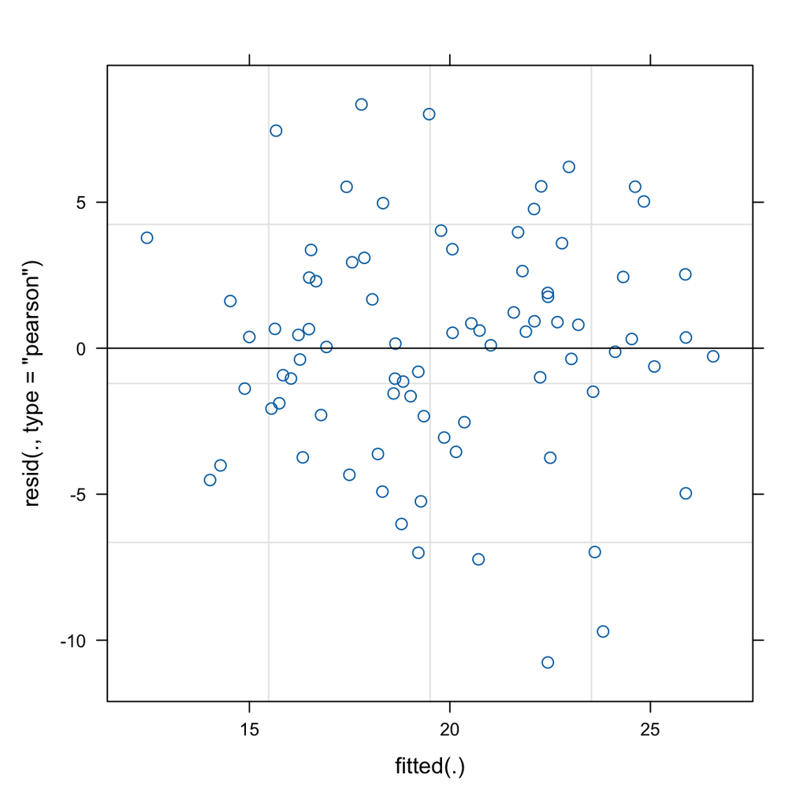

```r
plot(CEWL_LMM_best)
```

```r
shapiro.test(residuals(CEWL_LMM_best))
```

```
##
##  Shapiro-Wilk normality test
##
## data:  residuals(CEWL_LMM_best)
## W = 0.98789, p-value = 0.6492
```

## Partial Regression

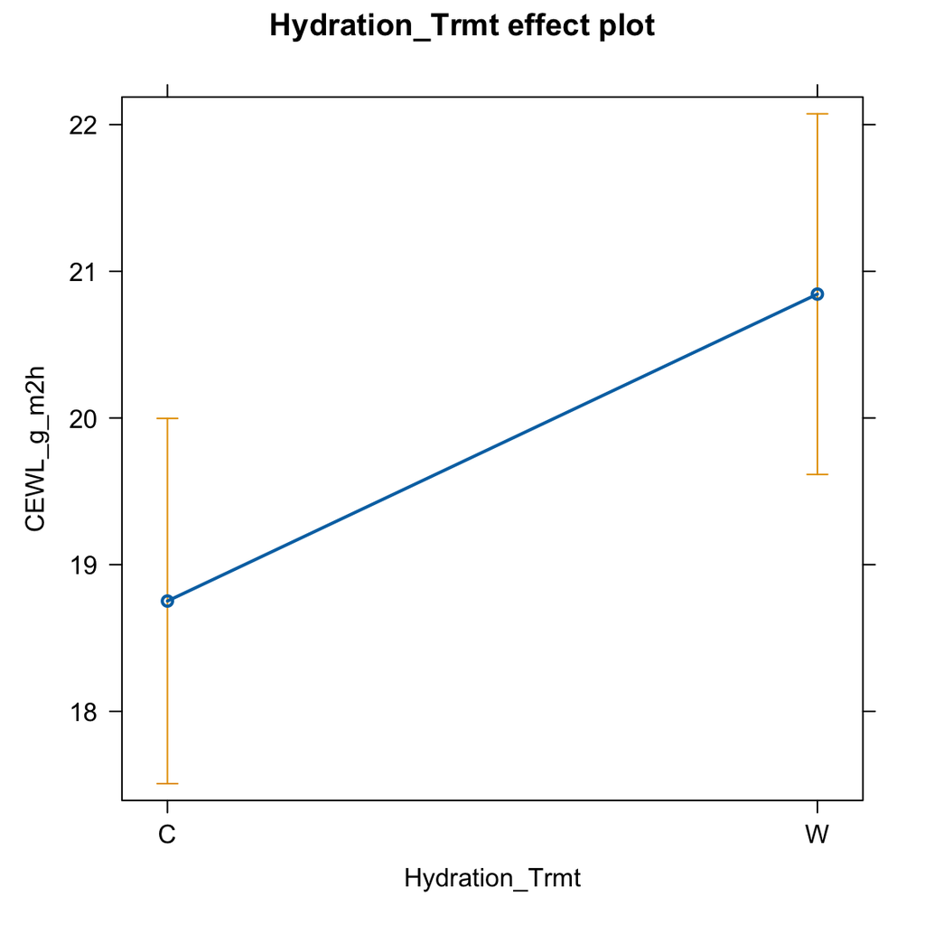

```r
plot(effect("Hydration_Trmt", CEWL_LMM_best))
```

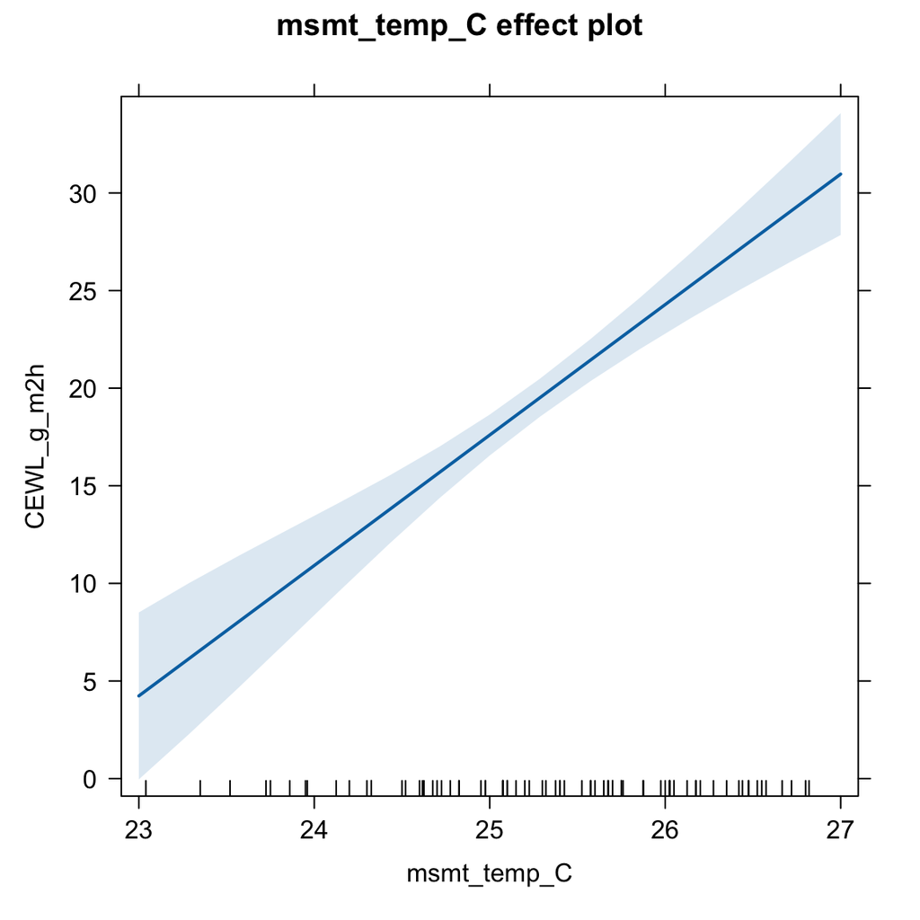

```r
plot(effect("msmt_temp_C", CEWL_LMM_best))
```

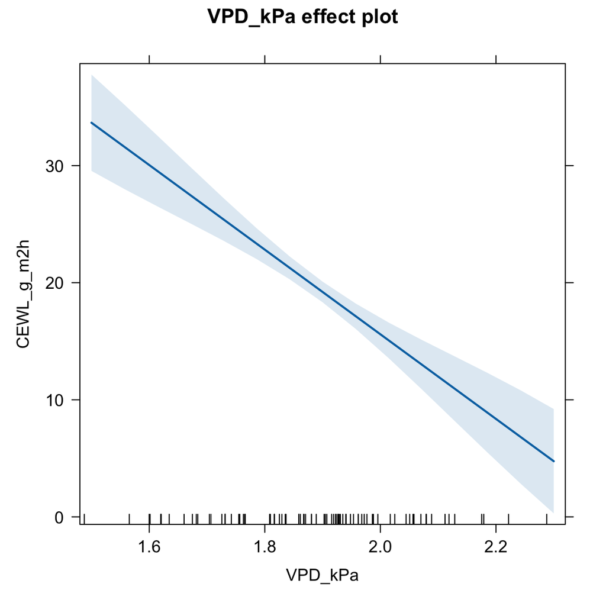

```r
plot(effect("VPD_kPa", CEWL_LMM_best))
```

```r
temp_effects_data <- summary(effect("msmt_temp_C", CEWL_LMM_best))

temp_effects_df <- data_frame(
  meanval = temp_effects_data$effect,
  lowCI = temp_effects_data$lower,
  highCI = temp_effects_data$upper
) %>%
  mutate(msmt_temp_C = c(23, 24, 25, 26, 27))

temp_effects_df
```

```
## # A tibble: 5 × 4
##     meanval     lowCI    highCI msmt_temp_C
##   <dbl[1d]> <dbl[1d]> <dbl[1d]>       <dbl>
## 1      4.23   -0.0434      8.51          23
## 2     10.9     8.37       13.5           24
## 3     17.6    16.6        18.6           25
## 4     24.3    22.8        25.8           26
## 5     31.0    27.8        34.1           27
```

```r
VPD_effects_data <- summary(effect("VPD_kPa", CEWL_LMM_best))

VPD_effects_df <- data_frame(
  meanval = VPD_effects_data$effect,
  lowCI = VPD_effects_data$lower,
  highCI = VPD_effects_data$upper
) %>%
  mutate(VPD_kPa = c(1.5, 1.7, 1.9, 2.1, 2.3))

VPD_effects_df
```

```
## # A tibble: 5 × 4
##     meanval     lowCI    highCI VPD_kPa
##   <dbl[1d]> <dbl[1d]> <dbl[1d]>   <dbl>
## 1     33.7     29.6       37.8      1.5
## 2     26.4     24.3       28.5      1.7
## 3     19.2     18.3       20.1      1.9
## 4     12.0      9.55      14.4      2.1
## 5      4.75     0.296      9.21     2.3
```

# PUB FIGURE

## CEWL ~ temp

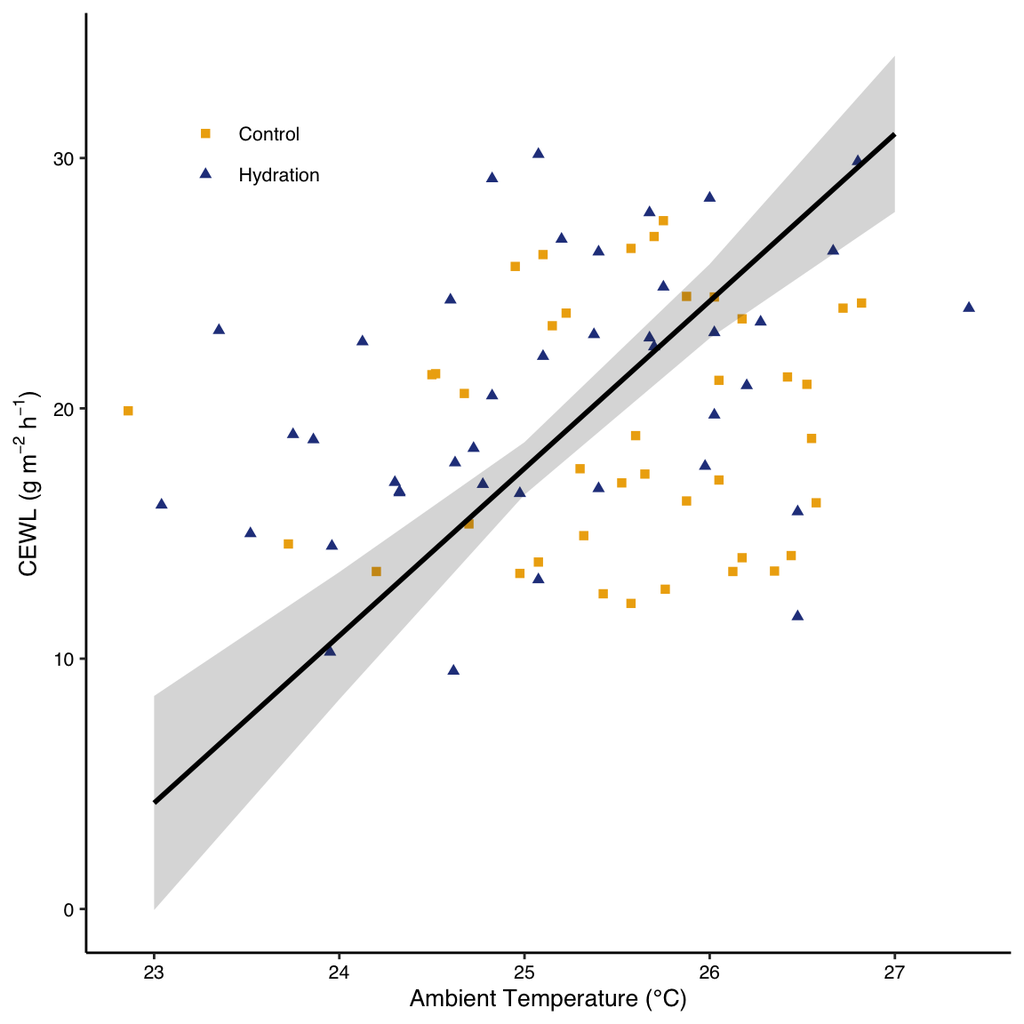

```r
ggplot() +
  geom_point(
    data = mother_data_all_final_full,
    aes(x = msmt_temp_C, y = CEWL_g_m2h,
        color = Hydration_Trmt, shape = Hydration_Trmt)
    ) +
  geom_ribbon(
    data = temp_effects_df,
    aes(x = msmt_temp_C, ymin = lowCI, ymax = highCI),
    alpha = 0.2
  ) +
  geom_line(
    data = temp_effects_df,
    aes(x = msmt_temp_C, y = meanval),
    color = "black",
    linewidth = 1
  ) +

  # prettys
  scale_color_manual(
    values = c("darkgoldenrod2", "royalblue4"),
    labels = c("C" = "Control", "W" = "Hydration"),
    name = NULL
  ) +
  scale_shape_manual(
    values = c(15, 17),
    labels = c("C" = "Control", "W" = "Hydration"),
    name = NULL
  ) +
  theme(
    legend.position = "inside",
    legend.position.inside = c(0.18, 0.85),
    legend.background = element_blank()
  ) +
  scale_x_continuous(
    name = "Ambient Temperature (\u00b0C)" # unicode for degree symbol
  ) +
  scale_y_continuous(
    breaks = c(0, 10, 20, 30),
    name = expression('CEWL (g '*m^-2*' '*h^-1*')')
  ) -> CEWL_temp_lm
CEWL_temp_lm
```

## CEWL ~ VPD

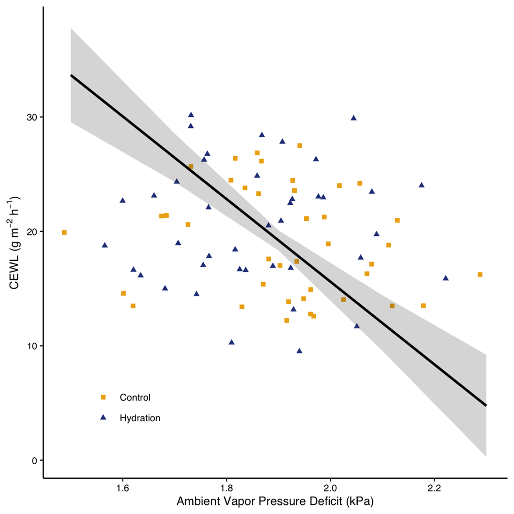

```r
ggplot() +
  geom_point(
    data = mother_data_all_final_full,
    aes(x = VPD_kPa, y = CEWL_g_m2h,
        color = Hydration_Trmt, shape = Hydration_Trmt)
    ) +
  geom_ribbon(
    data = VPD_effects_df,
    aes(x = VPD_kPa, ymin = lowCI, ymax = highCI),
    alpha = 0.2
  ) +
  geom_line(
    data = VPD_effects_df,
    aes(x = VPD_kPa, y = meanval),
    color = "black",
    linewidth = 1
  ) +

  # prettys
  scale_color_manual(
    values = c("darkgoldenrod2", "royalblue4"),
    labels = c("C" = "Control", "W" = "Hydration"),
    name = NULL
  ) +
  scale_shape_manual(
    values = c(15, 17),
    labels = c("C" = "Control", "W" = "Hydration"),
    name = NULL
  ) +
  theme(
    legend.position = "inside",
    legend.position.inside = c(0.18, 0.15),
    legend.background = element_blank()
  ) +
  scale_x_continuous(
    name = "Ambient Vapor Pressure Deficit (kPa)"
  ) +
  scale_y_continuous(
    breaks = c(0, 10, 20, 30),
    name = expression('CEWL (g '*m^-2*' '*h^-1*')')
  ) -> CEWL_VPD_lm
CEWL_VPD_lm
```

## arrange

```r
ggarrange(
  CEWL_temp_lm, CEWL_VPD_lm,
  nrow = 1,
  ncol = 2,
  labels = c("A", "B"),
  align = "hv"
) -> CEWL_lm_figs

ggsave(
  filename = "Fig2_mother_CEWL_temp_VPD.pdf",
  plot = CEWL_lm_figs,
  path = "./results_figures",
  device = "pdf",
  dpi = 600,
  units = "mm",
  width = 160,
  height = 60
)
ggsave(
  filename = "Fig2_mother_CEWL_temp_VPD.tiff",
  plot = CEWL_lm_figs,
  path = "./results_figures",
  device = "tiff",
  dpi = 600,
  units = "mm",
  width = 160,
  height = 60
)
```

# BASELINE OSMOL

check whether proximity to birthing date affected osmol:

```r
mothers_baseline_birthsnakes <- mothers_baseline %>%
  filter(Gave_Birth == "Y")

partur <- lm(data = mothers_baseline_birthsnakes,
             Plasma_Osmol_Rep_mean ~ Day_Relative)

summary(partur)
```

```
##
## Call:
## lm(formula = Plasma_Osmol_Rep_mean ~ Day_Relative, data = mothers_baseline_birthsnakes)
##
## Residuals:
##     Min      1Q  Median      3Q     Max
## -28.846 -14.133   1.881   6.096  44.803
##
## Coefficients:
##              Estimate Std. Error t value Pr(>|t|)
## (Intercept)   323.791      8.968  36.103   <2e-16 ***
## Day_Relative   -1.055      0.956  -1.103    0.286
## ---
## Signif. codes:  0 '***' 0.001 '**' 0.01 '*' 0.05 '.' 0.1 ' ' 1
##
## Residual standard error: 20.59 on 16 degrees of freedom
##   (1 observation deleted due to missingness)
## Multiple R-squared:  0.07069,    Adjusted R-squared:  0.0126
## F-statistic: 1.217 on 1 and 16 DF,  p-value: 0.2863
```

```r
car::Anova(partur, type = "2")
```

```
## Anova Table (Type II tests)
##
## Response: Plasma_Osmol_Rep_mean
##              Sum Sq Df F value Pr(>F)
## Day_Relative  515.9  1   1.217 0.2863
## Residuals    6782.4 16
```

Day relative to birth was not significant. Will run all individuals in one model.

```r
baseline_osmol_1 <- lme4::lmer(data = mothers_baseline,
                      Plasma_Osmol_Rep_mean ~
                        Mass_g +
                        SVL_cm +
                        (1|CEWL_Blood_Collect_Date))
summary(baseline_osmol_1)
```

```
## Linear mixed model fit by REML ['lmerMod']
## Formula:
## Plasma_Osmol_Rep_mean ~ Mass_g + SVL_cm + (1 | CEWL_Blood_Collect_Date)
##    Data: mothers_baseline
##
## REML criterion at convergence: 247.1
##
## Scaled residuals:
##     Min      1Q  Median      3Q     Max
## -1.8030 -0.6821 -0.1614  0.4783  2.5978
##
## Random effects:
##  Groups                  Name        Variance Std.Dev.
##  CEWL_Blood_Collect_Date (Intercept)   0.0     0.00
##  Residual                            328.6    18.13
## Number of obs: 29, groups:  CEWL_Blood_Collect_Date, 5
##
## Fixed effects:
##              Estimate Std. Error t value
## (Intercept) 226.90678   45.58856   4.977
## Mass_g       -0.07239    0.04368  -1.657
## SVL_cm        1.70903    0.74845   2.283
##
## Correlation of Fixed Effects:
##        (Intr) Mass_g
## Mass_g  0.524
## SVL_cm -0.952 -0.755
## optimizer (nloptwrap) convergence code: 0 (OK)
## boundary (singular) fit: see help('isSingular')
```

```r
drop1(baseline_osmol_1)
```

```
## Single term deletions
##
## Model:
## Plasma_Osmol_Rep_mean ~ Mass_g + SVL_cm + (1 | CEWL_Blood_Collect_Date)
##        npar    AIC
## <none>      257.18
## Mass_g    1 258.10
## SVL_cm    1 260.48
```

The capture date didn’t account for any of the variance so first dropping the random effect.

```r
baseline_osmol_2 <- lm(data = mothers_baseline,
                      Plasma_Osmol_Rep_mean ~
                        Mass_g +
                        SVL_cm)

drop1(baseline_osmol_2)
```

```
## Single term deletions
##
## Model:
## Plasma_Osmol_Rep_mean ~ Mass_g + SVL_cm
##        Df Sum of Sq     RSS    AIC
## <none>               8544.1 170.88
## Mass_g  1    902.74  9446.9 171.80
## SVL_cm  1   1713.44 10257.6 174.19
```

```r
baseline_osmol_3 <- lm(data = mothers_baseline,
                      Plasma_Osmol_Rep_mean ~
                        SVL_cm)

anova(baseline_osmol_3)
```

```
## Analysis of Variance Table
##
## Response: Plasma_Osmol_Rep_mean
##           Df Sum Sq Mean Sq F value Pr(>F)
## SVL_cm     1  814.2  814.19   2.327 0.1388
## Residuals 27 9446.9  349.88
```

```r
baseline_osmol_null <- lm(data = mothers_baseline,
                      Plasma_Osmol_Rep_mean ~ 1)
```

## Model selection

```r
baseline_osmol_mods <- list(baseline_osmol_2,
                            baseline_osmol_3,
                            baseline_osmol_null)

#specify model names
baeline_osmol_mod_names_all <- c('model2', 'model3', 'modelnull')

#calculate AIC of each model
cewl_AICc_all <- data.frame(aictab(cand.set = baseline_osmol_mods,
                                 modnames = baeline_osmol_mod_names_all))
cewl_AICc_all
```

```
##    Modnames K     AICc Delta_AICc  ModelLik    AICcWt        LL    Cum.Wt
## 1    model2 4 256.8505  0.0000000 1.0000000 0.3507677 -123.5919 0.3507677
## 3 modelnull 2 256.9557  0.1051271 0.9487940 0.3328063 -126.2471 0.6835740
## 2    model3 3 257.0566  0.2060697 0.9020955 0.3164260 -125.0483 1.0000000
```

They are all equivalently bad.

## No Final Model

****Remember that birthing effecting osmolality, so we created two separate models for the snakes that gave birth and those that didn’t. See both below.

# EXP OSMOL - BIRTH MOTHERS

```r
BirthSnakes_LMM_0 <- lme4::lmer(data = birth_snakes,
                      Plasma_Osmol_Rep_mean ~
                        Hydration_Trmt *
                        (Days_in_Treatment + live_neonates) +
                        Day_Relative +
                        Mass_g +
                        SVL_cm +
                        (1|Indiv_ID))

car::vif(BirthSnakes_LMM_0)
```

```
##                   Hydration_Trmt                Days_in_Treatment
##                        24.551693                         3.177321
##                    live_neonates                     Day_Relative
##                         3.306380                         2.831170
##                           Mass_g                           SVL_cm
##                         2.334687                         2.091597
## Hydration_Trmt:Days_in_Treatment     Hydration_Trmt:live_neonates
##                         2.616349                        24.726405
```

```r
BirthSnakes_LMM_0.1 <- lme4::lmer(data = birth_snakes,
                      Plasma_Osmol_Rep_mean ~
                        Hydration_Trmt *
                        Days_in_Treatment +
                        live_neonates +
                        Day_Relative +
                        Mass_g +
                        SVL_cm +
                        (1|Indiv_ID))

car::vif(BirthSnakes_LMM_0.1)
```

```
##                   Hydration_Trmt                Days_in_Treatment
##                         1.947985                         2.981160
##                    live_neonates                     Day_Relative
##                         1.333067                         2.380202
##                           Mass_g                           SVL_cm
##                         2.136163                         2.062318
## Hydration_Trmt:Days_in_Treatment
##                         2.642105
```

```r
drop1(BirthSnakes_LMM_0.1)
```

```
## Single term deletions
##
## Model:
## Plasma_Osmol_Rep_mean ~ Hydration_Trmt * Days_in_Treatment +
##     live_neonates + Day_Relative + Mass_g + SVL_cm + (1 | Indiv_ID)
##                                  npar    AIC
## <none>                                440.48
## live_neonates                       1 438.84
## Day_Relative                        1 448.13
## Mass_g                              1 438.51
## SVL_cm                              1 438.91
## Hydration_Trmt:Days_in_Treatment    1 454.76
```

```r
BirthSnakes_LMM_1 <- lme4::lmer(data = birth_snakes,
                      Plasma_Osmol_Rep_mean ~
                        Hydration_Trmt *
                        Days_in_Treatment +
                        Day_Relative +
                        Mass_g +
                        SVL_cm +
                        (1|Indiv_ID))

drop1(BirthSnakes_LMM_1)
```

```
## Single term deletions
##
## Model:
## Plasma_Osmol_Rep_mean ~ Hydration_Trmt * Days_in_Treatment +
##     Day_Relative + Mass_g + SVL_cm + (1 | Indiv_ID)
##                                  npar    AIC
## <none>                                438.84
## Day_Relative                        1 446.80
## Mass_g                              1 436.85
## SVL_cm                              1 437.08
## Hydration_Trmt:Days_in_Treatment    1 453.57
```

```r
BirthSnakes_LMM_2a <- lme4::lmer(data = birth_snakes,
                      Plasma_Osmol_Rep_mean ~
                        Hydration_Trmt *
                        Days_in_Treatment +
                        Day_Relative +
                        SVL_cm +
                        (1|Indiv_ID))

drop1(BirthSnakes_LMM_2a)
```

```
## Single term deletions
##
## Model:
## Plasma_Osmol_Rep_mean ~ Hydration_Trmt * Days_in_Treatment +
##     Day_Relative + SVL_cm + (1 | Indiv_ID)
##                                  npar    AIC
## <none>                                436.85
## Day_Relative                        1 445.55
## SVL_cm                              1 435.25
## Hydration_Trmt:Days_in_Treatment    1 451.59
```

```r
BirthSnakes_LMM_2 <- lme4::lmer(data = birth_snakes,
                      Plasma_Osmol_Rep_mean ~
                        Hydration_Trmt *
                        Days_in_Treatment +
                        Day_Relative +
                        (1|Indiv_ID))

drop1(BirthSnakes_LMM_2)
```

```
## Single term deletions
##
## Model:
## Plasma_Osmol_Rep_mean ~ Hydration_Trmt * Days_in_Treatment +
##     Day_Relative + (1 | Indiv_ID)
##                                  npar    AIC
## <none>                                435.25
## Day_Relative                        1 447.36
## Hydration_Trmt:Days_in_Treatment    1 449.63
```

```r
BirthSnakes_LMM_3 <- lme4::lmer(data = birth_snakes,
                      Plasma_Osmol_Rep_mean ~
                        Hydration_Trmt *
                        Days_in_Treatment +
                        (1|Indiv_ID))
```

```r
BirthSnakes_LMM_4 <- lme4::lmer(data = birth_snakes,
                      Plasma_Osmol_Rep_mean ~
                        Hydration_Trmt +
                        Days_in_Treatment +
                        (1|Indiv_ID))

drop1(BirthSnakes_LMM_4)
```

```
## Single term deletions
##
## Model:
## Plasma_Osmol_Rep_mean ~ Hydration_Trmt + Days_in_Treatment +
##     (1 | Indiv_ID)
##                   npar    AIC
## <none>                 461.27
## Hydration_Trmt       1 459.28
## Days_in_Treatment    1 461.65
```

```r
BirthSnakes_LMM_5 <- lme4::lmer(data = birth_snakes,
                      Plasma_Osmol_Rep_mean ~
                        Days_in_Treatment +
                        (1|Indiv_ID))
```

```r
BirthSnakes_LMM_null<- lme4::lmer(data = birth_snakes,
                      Plasma_Osmol_Rep_mean ~ 1 +
                        (1|Indiv_ID))
```

## Model selection

```r
osmolarity_models <- list(BirthSnakes_LMM_0.1, BirthSnakes_LMM_1,
                          BirthSnakes_LMM_2a, BirthSnakes_LMM_2,
                          BirthSnakes_LMM_3, BirthSnakes_LMM_4,
                          BirthSnakes_LMM_5, BirthSnakes_LMM_null)

#specify model names
osmolarity_mod_names <- c('model0', 'model1',
                    'model2a',  'model2',
                    'model3',
                    'model4',
                    'model5',
                    'modelnull')

#calculate AIC of each model
osmolarity_AICc <- data.frame(aictab(cand.set = osmolarity_models,
                                 modnames = osmolarity_mod_names))
osmolarity_AICc
```

```
##    Modnames  K     AICc Delta_AICc     ModelLik       AICcWt    Res.LL
## 4    model2  7 427.8382   0.000000 1.000000e+00 7.436985e-01 -205.6168
## 3   model2a  8 430.0590   2.220801 3.294269e-01 2.449943e-01 -205.3152
## 5    model3  6 437.8971  10.058876 6.542486e-03 4.865637e-03 -211.9940
## 2    model1  9 438.6015  10.763308 4.600208e-03 3.421167e-03 -208.1056
## 1    model0 10 438.8541  11.015858 4.054496e-03 3.015322e-03 -206.6770
## 6    model4  5 452.2280  24.389778 5.056231e-06 3.760312e-06 -220.4473
## 7    model5  4 455.4211  27.582943 1.024331e-06 7.617931e-07 -223.2758
## 8 modelnull  3 456.1672  28.329010 7.053971e-07 5.246028e-07 -224.8283
##      Cum.Wt
## 4 0.7436985
## 3 0.9886928
## 5 0.9935585
## 2 0.9969796
## 1 0.9999950
## 6 0.9999987
## 7 0.9999995
## 8 1.0000000
```

## Final model

```r
BirthSnakes_LMM_best <- lmerTest::lmer(data = birth_snakes,
                      Plasma_Osmol_Rep_mean ~
                        Hydration_Trmt *
                        Days_in_Treatment +
                        Day_Relative +
                        (1|Indiv_ID))

summary(BirthSnakes_LMM_best)
```

```
## Linear mixed model fit by REML. t-tests use Satterthwaite's method [
## lmerModLmerTest]
## Formula: Plasma_Osmol_Rep_mean ~ Hydration_Trmt * Days_in_Treatment +
##     Day_Relative + (1 | Indiv_ID)
##    Data: birth_snakes
##
## REML criterion at convergence: 411.2
##
## Scaled residuals:
##     Min      1Q  Median      3Q     Max
## -1.8867 -0.7229 -0.1191  0.7561  1.9373
##
## Random effects:
##  Groups   Name        Variance Std.Dev.
##  Indiv_ID (Intercept)  12.99    3.604
##  Residual             239.12   15.464
## Number of obs: 51, groups:  Indiv_ID, 18
##
## Fixed effects:
##                                   Estimate Std. Error       df t value Pr(>|t|)
## (Intercept)                       305.0576     5.6221  22.6743  54.260  < 2e-16
## Hydration_TrmtW                    20.0117     6.6176  38.9722   3.024 0.004398
## Days_in_Treatment                   2.1606     0.6390  34.5035   3.381 0.001807
## Day_Relative                       -1.9638     0.4811  18.6902  -4.082 0.000654
## Hydration_TrmtW:Days_in_Treatment  -3.5833     0.8386  40.7404  -4.273 0.000113
##
## (Intercept)                       ***
## Hydration_TrmtW                   **
## Days_in_Treatment                 **
## Day_Relative                      ***
## Hydration_TrmtW:Days_in_Treatment ***
## ---
## Signif. codes:  0 '***' 0.001 '**' 0.01 '*' 0.05 '.' 0.1 ' ' 1
##
## Correlation of Fixed Effects:
##             (Intr) Hyd_TW Dys__T Dy_Rlt
## Hydrtn_TrmW -0.582
## Dys_n_Trtmn -0.784  0.424
## Day_Relativ  0.526  0.062 -0.475
## Hyd_TW:D__T  0.375 -0.706 -0.562 -0.059
```

```r
r.squaredGLMM(BirthSnakes_LMM_best)
```

```
##            R2m       R2c
## [1,] 0.4509044 0.4791947
```

```r
anova(BirthSnakes_LMM_best, test = "F", type = "2")
```

```
## Type II Analysis of Variance Table with Satterthwaite's method
##                                  Sum Sq Mean Sq NumDF  DenDF F value    Pr(>F)
## Hydration_Trmt                   2186.7  2186.7     1 38.972  9.1447 0.0043976
## Days_in_Treatment                 349.6   349.6     1 25.059  1.4621 0.2378755
## Day_Relative                     3984.7  3984.7     1 18.690 16.6641 0.0006539
## Hydration_Trmt:Days_in_Treatment 4366.3  4366.3     1 40.740 18.2600 0.0001128
##
## Hydration_Trmt                   **
## Days_in_Treatment
## Day_Relative                     ***
## Hydration_Trmt:Days_in_Treatment ***
## ---
## Signif. codes:  0 '***' 0.001 '**' 0.01 '*' 0.05 '.' 0.1 ' ' 1
```

```r
tidy(emtrends(BirthSnakes_LMM_best,
         "Hydration_Trmt", var = "Days_in_Treatment"))
```

```
## # A tibble: 2 × 6
##   Hydration_Trmt Days_in_Treatment.trend std.error    df statistic p.value
##   <chr>                            <dbl>     <dbl> <dbl>     <dbl>   <dbl>
## 1 C                                 2.16     0.649  33.2      3.33 0.00214
## 2 W                                -1.42     0.719  42.5     -1.98 0.0542
```

```r
pairs(emtrends(BirthSnakes_LMM_2,
               "Hydration_Trmt", var = "Days_in_Treatment"))
```

```
##  contrast estimate    SE df t.ratio p.value
##  C - W        3.58 0.858 40   4.176  0.0002
##
## Degrees-of-freedom method: kenward-roger
```

## Model assumptions

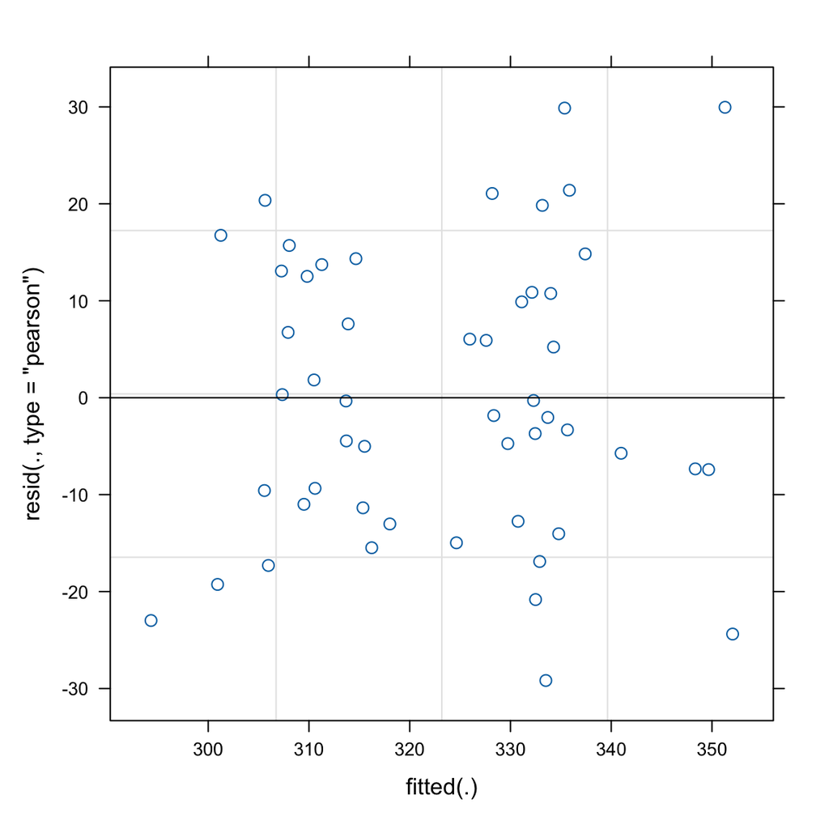

```r
plot(BirthSnakes_LMM_best)
```

```r
shapiro.test(residuals(BirthSnakes_LMM_best))
```

```
##
##  Shapiro-Wilk normality test
##
## data:  residuals(BirthSnakes_LMM_best)
## W = 0.98162, p-value = 0.6092
```

## Partial Regression

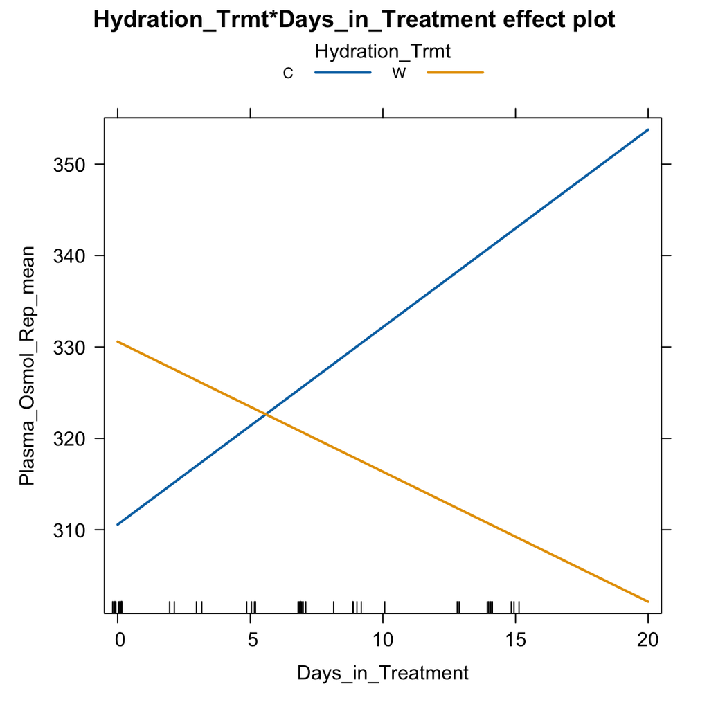

```r
plot(effect("Hydration_Trmt:Days_in_Treatment",
            BirthSnakes_LMM_best), multiline = TRUE)
```

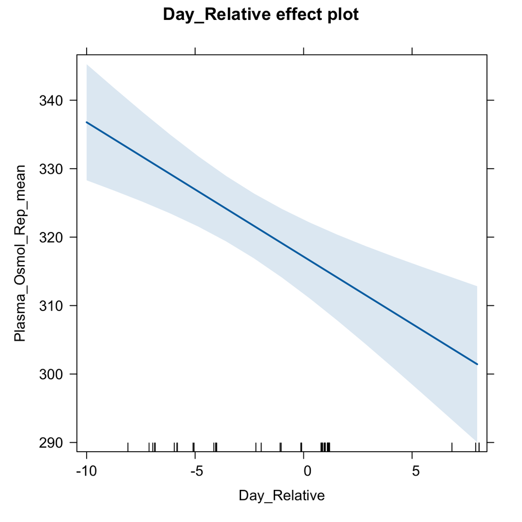

```r
plot(effect("Day_Relative", BirthSnakes_LMM_best))
```

```r
int_effects_data <- summary(effect("Hydration_Trmt:Days_in_Treatment", BirthSnakes_LMM_best))

as.data.frame(int_effects_data$effect)
```

```
##          0        4        8       10       20
## C 310.5639 319.2064 327.8488 332.1700 353.7761
## W 330.5757 324.8848 319.1939 316.3484 302.1212
```

# EXP OSMOL - NO BIRTH

```r
No_BirthSnakes_LMM_1 <- lme4::lmer(data = no_birth_snakes,
                      Plasma_Osmol_Rep_mean ~
                        Hydration_Trmt *
                        Days_in_Treatment +
                        Mass_g +
                        SVL_cm +
                        (1|Indiv_ID))

drop1(No_BirthSnakes_LMM_1)
```

```
## Single term deletions
##
## Model:
## Plasma_Osmol_Rep_mean ~ Hydration_Trmt * Days_in_Treatment +
##     Mass_g + SVL_cm + (1 | Indiv_ID)
##                                  npar    AIC
## <none>                                222.36
## Mass_g                              1 223.51
## SVL_cm                              1 223.63
## Hydration_Trmt:Days_in_Treatment    1 235.61
```

```r
anova(No_BirthSnakes_LMM_1)
```

```
## Analysis of Variance Table
##                                  npar  Sum Sq Mean Sq F value
## Hydration_Trmt                      1  300.95  300.95  2.3689
## Days_in_Treatment                   1  288.60  288.60  2.2717
## Mass_g                              1  151.73  151.73  1.1943
## SVL_cm                              1 1408.42 1408.42 11.0863
## Hydration_Trmt:Days_in_Treatment    1 2078.28 2078.28 16.3591
```

```r
No_BirthSnakes_LMM_1a <- lme4::lmer(data = no_birth_snakes,
                      Plasma_Osmol_Rep_mean ~
                        Hydration_Trmt *
                        Days_in_Treatment +
                        SVL_cm +
                        (1|Indiv_ID))

drop1(No_BirthSnakes_LMM_1a)
```

```
## Single term deletions
##
## Model:
## Plasma_Osmol_Rep_mean ~ Hydration_Trmt * Days_in_Treatment +
##     SVL_cm + (1 | Indiv_ID)
##                                  npar    AIC
## <none>                                223.51
## SVL_cm                              1 221.69
## Hydration_Trmt:Days_in_Treatment    1 240.06
```

```r
No_BirthSnakes_LMM_1b <- lme4::lmer(data = no_birth_snakes,
                      Plasma_Osmol_Rep_mean ~
                        Hydration_Trmt *
                        Days_in_Treatment +
                        (1|Indiv_ID))
```

```r
No_BirthSnakes_LMM_2 <- lme4::lmer(data = no_birth_snakes,
                      Plasma_Osmol_Rep_mean ~
                        Hydration_Trmt +
                        Days_in_Treatment +
                        (1|Indiv_ID))

drop1(No_BirthSnakes_LMM_2)
```

```
## Single term deletions
##
## Model:
## Plasma_Osmol_Rep_mean ~ Hydration_Trmt + Days_in_Treatment +
##     (1 | Indiv_ID)
##                   npar    AIC
## <none>                 238.24
## Hydration_Trmt       1 238.07
## Days_in_Treatment    1 237.01
```

```r
No_BirthSnakes_LMM_3 <- lme4::lmer(data = no_birth_snakes,
                      Plasma_Osmol_Rep_mean ~
                        Hydration_Trmt +
                        (1|Indiv_ID))
summary(No_BirthSnakes_LMM_3) # raneff no longer explains any variation
```

```
## Linear mixed model fit by REML ['lmerMod']
## Formula: Plasma_Osmol_Rep_mean ~ Hydration_Trmt + (1 | Indiv_ID)
##    Data: no_birth_snakes
##
## REML criterion at convergence: 219.2
##
## Scaled residuals:
##      Min       1Q   Median       3Q      Max
## -1.52483 -0.75645 -0.01749  0.69802  1.55942
##
## Random effects:
##  Groups   Name        Variance Std.Dev.
##  Indiv_ID (Intercept)   0.0     0.00
##  Residual             305.2    17.47
## Number of obs: 27, groups:  Indiv_ID, 10
##
## Fixed effects:
##                 Estimate Std. Error t value
## (Intercept)      327.090      5.043  64.858
## Hydration_TrmtW   -9.785      6.766  -1.446
##
## Correlation of Fixed Effects:
##             (Intr)
## Hydrtn_TrmW -0.745
## optimizer (nloptwrap) convergence code: 0 (OK)
## boundary (singular) fit: see help('isSingular')
```

```r
No_BirthSnakes_LMM_null <- lme4::lmer(data = no_birth_snakes,
                      Plasma_Osmol_Rep_mean ~ 1 +
                        (1|Indiv_ID))
```

## Model selection

```r
osmolarity_models_nb <- list(No_BirthSnakes_LMM_1,
                             No_BirthSnakes_LMM_1a, No_BirthSnakes_LMM_1b,
                          No_BirthSnakes_LMM_2,
                          No_BirthSnakes_LMM_3,
                          No_BirthSnakes_LMM_null)

#specify model names
osmolarity_mod_names_nb <- c('model1', 'model1a', 'model1b',
                    'model2',
                    'model3',
                    'modelnull')

#calculate AIC of each model
osmolarity_AICc_nb <- data.frame(aictab(cand.set = osmolarity_models_nb,
                                 modnames = osmolarity_mod_names_nb))
osmolarity_AICc_nb
```

```
##    Modnames K     AICc Delta_AICc     ModelLik       AICcWt     Res.LL
## 3   model1b 6 215.3545   0.000000 1.0000000000 8.142405e-01  -99.57726
## 2   model1a 7 218.5101   3.155542 0.2064346852 1.680875e-01  -99.30767
## 1    model1 8 223.1806   7.826109 0.0199793788 1.626802e-02  -99.59032
## 5    model3 4 228.9824  13.627860 0.0010983677 8.943354e-04 -109.58210
## 4    model2 5 230.4293  15.074745 0.0005327956 4.338238e-04 -108.78607
## 6 modelnull 3 233.9177  18.563151 0.0000931243 7.582557e-05 -113.43710
##      Cum.Wt
## 3 0.8142405
## 2 0.9823280
## 1 0.9985960
## 5 0.9994904
## 4 0.9999242
## 6 1.0000000
```

## Final model

Best model is 1b

```r
No_BirthSnakes_LMM_best <- lmerTest::lmer(data = no_birth_snakes,
                      Plasma_Osmol_Rep_mean ~
                        Hydration_Trmt *
                        Days_in_Treatment +
                        (1|Indiv_ID))

summary(No_BirthSnakes_LMM_best)
```

```
## Linear mixed model fit by REML. t-tests use Satterthwaite's method [
## lmerModLmerTest]
## Formula: Plasma_Osmol_Rep_mean ~ Hydration_Trmt * Days_in_Treatment +
##     (1 | Indiv_ID)
##    Data: no_birth_snakes
##
## REML criterion at convergence: 199.2
##
## Scaled residuals:
##     Min      1Q  Median      3Q     Max
## -1.6454 -0.6974 -0.1435  0.8136  1.4615
##
## Random effects:
##  Groups   Name        Variance Std.Dev.
##  Indiv_ID (Intercept)  31.01    5.568
##  Residual             136.17   11.669
## Number of obs: 27, groups:  Indiv_ID, 10
##
## Fixed effects:
##                                   Estimate Std. Error       df t value Pr(>|t|)
## (Intercept)                       315.9304     5.4872  19.0315  57.576  < 2e-16
## Hydration_TrmtW                    16.9397     7.6888  18.7885   2.203 0.040270
## Days_in_Treatment                   2.0423     0.6755  16.7699   3.024 0.007748
## Hydration_TrmtW:Days_in_Treatment  -4.2872     0.8613  15.9036  -4.978 0.000139
##
## (Intercept)                       ***
## Hydration_TrmtW                   *
## Days_in_Treatment                 **
## Hydration_TrmtW:Days_in_Treatment ***
## ---
## Signif. codes:  0 '***' 0.001 '**' 0.01 '*' 0.05 '.' 0.1 ' ' 1
##
## Correlation of Fixed Effects:
##             (Intr) Hyd_TW Dys__T
## Hydrtn_TrmW -0.714
## Dys_n_Trtmn -0.642  0.458
## Hyd_TW:D__T  0.503 -0.658 -0.784
```

```r
r.squaredGLMM(No_BirthSnakes_LMM_best)
```

```
##            R2m       R2c
## [1,] 0.4974886 0.5906876
```

```r
anova(No_BirthSnakes_LMM_best, test = "F", type = "2")
```

```
## Type II Analysis of Variance Table with Satterthwaite's method
##                                  Sum Sq Mean Sq NumDF  DenDF F value    Pr(>F)
## Hydration_Trmt                    661.0   661.0     1 18.788  4.8540 0.0402696
## Days_in_Treatment                 237.7   237.7     1 15.436  1.7456 0.2056842
## Hydration_Trmt:Days_in_Treatment 3374.0  3374.0     1 15.904 24.7773 0.0001393
##
## Hydration_Trmt                   *
## Days_in_Treatment
## Hydration_Trmt:Days_in_Treatment ***
## ---
## Signif. codes:  0 '***' 0.001 '**' 0.01 '*' 0.05 '.' 0.1 ' ' 1
```

```r
tidy(emtrends(No_BirthSnakes_LMM_best,
         "Hydration_Trmt", var = "Days_in_Treatment"))
```

```
## # A tibble: 2 × 6
##   Hydration_Trmt Days_in_Treatment.trend std.error    df statistic  p.value
##   <chr>                            <dbl>     <dbl> <dbl>     <dbl>    <dbl>
## 1 C                                 2.04     0.691  17.2      2.95 0.00877
## 2 W                                -2.24     0.534  15.1     -4.20 0.000761
```

```r
pairs(emtrends(No_BirthSnakes_LMM_best,
               "Hydration_Trmt", var = "Days_in_Treatment"))
```

```
##  contrast estimate    SE   df t.ratio p.value
##  C - W        4.29 0.874 16.4   4.907  0.0001
##
## Degrees-of-freedom method: kenward-roger
```

## Model assumptions

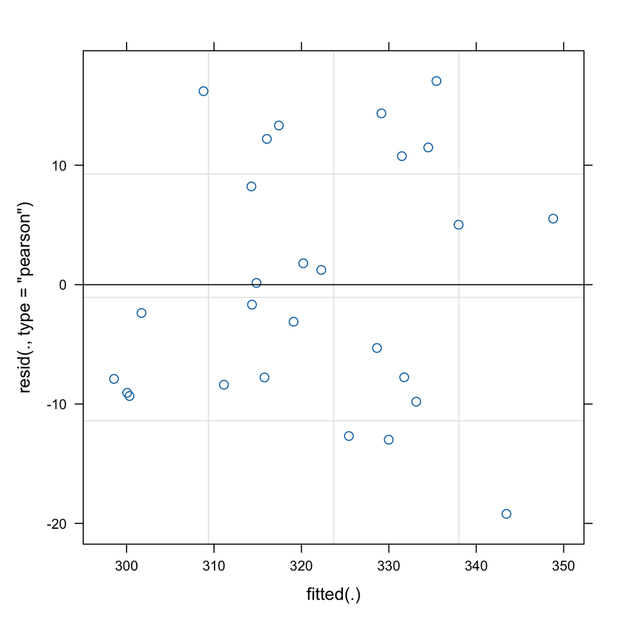

```r
plot(No_BirthSnakes_LMM_best)
```

```r
shapiro.test(residuals(No_BirthSnakes_LMM_best))
```

```
##
##  Shapiro-Wilk normality test
##
## data:  residuals(No_BirthSnakes_LMM_best)
## W = 0.94921, p-value = 0.2051
```

# CEWL vs Osmolarity

## All values

```r
cewl_osmol_lm <- lm(data = mother_data_all_final_full,
                    CEWL_g_m2h ~ Plasma_Osmol_Rep_mean)
summary(cewl_osmol_lm)
```

```
##
## Call:
## lm(formula = CEWL_g_m2h ~ Plasma_Osmol_Rep_mean, data = mother_data_all_final_full)
##
## Residuals:
##     Min      1Q  Median      3Q     Max
## -10.319  -3.534   0.581   4.123  10.319
##
## Coefficients:
##                       Estimate Std. Error t value Pr(>|t|)
## (Intercept)           14.67168    9.34254   1.570    0.120
## Plasma_Osmol_Rep_mean  0.01592    0.02889   0.551    0.583
##
## Residual standard error: 5.102 on 79 degrees of freedom
## Multiple R-squared:  0.00383,    Adjusted R-squared:  -0.008779
## F-statistic: 0.3038 on 1 and 79 DF,  p-value: 0.5831
```

```r
cewl_osmol_lm_2 <- lm(data = mother_data_all_final_full,
                    Plasma_Osmol_Rep_mean ~ CEWL_g_m2h)
summary(cewl_osmol_lm_2)
```

```
##
## Call:
## lm(formula = Plasma_Osmol_Rep_mean ~ CEWL_g_m2h, data = mother_data_all_final_full)
##
## Residuals:
##     Min      1Q  Median      3Q     Max
## -52.249 -11.130   0.629  11.377  56.044
##
## Coefficients:
##             Estimate Std. Error t value Pr(>|t|)
## (Intercept) 318.0223     8.9235  35.639   <2e-16 ***
## CEWL_g_m2h    0.2406     0.4365   0.551    0.583
## ---
## Signif. codes:  0 '***' 0.001 '**' 0.01 '*' 0.05 '.' 0.1 ' ' 1
##
## Residual standard error: 19.83 on 79 degrees of freedom
## Multiple R-squared:  0.00383,    Adjusted R-squared:  -0.008779
## F-statistic: 0.3038 on 1 and 79 DF,  p-value: 0.5831
```

## Split by timing

```r
mothers_DAC <- mother_data_all_final_full %>%
  filter(Preg_Stage == "DAC")

mothers_DAB <- mother_data_all_final_full %>%
  filter(Preg_Stage == "DAB")

mothers_1WAC <- mother_data_all_final_full %>%
  filter(Preg_Stage == "1WAC")
```

## Day after capture

```r
dac_lm <- lm(data = mothers_DAC, CEWL_g_m2h ~ Plasma_Osmol_Rep_mean)
summary(dac_lm)
```

```
##
## Call:
## lm(formula = CEWL_g_m2h ~ Plasma_Osmol_Rep_mean, data = mothers_DAC)
##
## Residuals:
##    Min     1Q Median     3Q    Max
## -7.867 -2.532  1.117  1.710  7.272
##
## Coefficients:
##                       Estimate Std. Error t value Pr(>|t|)
## (Intercept)           -8.83274   12.85160  -0.687   0.4978
## Plasma_Osmol_Rep_mean  0.09787    0.03919   2.497   0.0189 *
## ---
## Signif. codes:  0 '***' 0.001 '**' 0.01 '*' 0.05 '.' 0.1 ' ' 1
##
## Residual standard error: 3.97 on 27 degrees of freedom
## Multiple R-squared:  0.1877, Adjusted R-squared:  0.1576
## F-statistic: 6.238 on 1 and 27 DF,  p-value: 0.0189
```

```r
anova(dac_lm)
```

```
## Analysis of Variance Table
##
## Response: CEWL_g_m2h
##                       Df Sum Sq Mean Sq F value Pr(>F)
## Plasma_Osmol_Rep_mean  1  98.29  98.293  6.2375 0.0189 *
## Residuals             27 425.48  15.758
## ---
## Signif. codes:  0 '***' 0.001 '**' 0.01 '*' 0.05 '.' 0.1 ' ' 1
```

## Day after birth

```r
dab_lm <- lm(data = mothers_DAB, CEWL_g_m2h ~ Plasma_Osmol_Rep_mean)
summary(dab_lm)
```

```
##
## Call:
## lm(formula = CEWL_g_m2h ~ Plasma_Osmol_Rep_mean, data = mothers_DAB)
##
## Residuals:
##     Min      1Q  Median      3Q     Max
## -8.8059 -1.6214  0.8799  1.7608  8.3614
##
## Coefficients:
##                       Estimate Std. Error t value Pr(>|t|)
## (Intercept)            8.25334   20.33081   0.406    0.690
## Plasma_Osmol_Rep_mean  0.03498    0.06476   0.540    0.597
##
## Residual standard error: 4.533 on 16 degrees of freedom
## Multiple R-squared:  0.01791,    Adjusted R-squared:  -0.04347
## F-statistic: 0.2917 on 1 and 16 DF,  p-value: 0.5966
```

```r
anova(dab_lm)
```

```
## Analysis of Variance Table
##
## Response: CEWL_g_m2h
##                       Df Sum Sq Mean Sq F value Pr(>F)
## Plasma_Osmol_Rep_mean  1   5.99  5.9937  0.2917 0.5966
## Residuals             16 328.74 20.5460
```

# TMT EFFECTS

Use a subset of data to examine only the effect of supplemental hydration: compare maternal plasma osmolality, CEWL, and body mass recorded the day after capture versus measurements taken after one week in treatment.

Run LMM with individual ID as a random effect (2 obs per ind), followed by pairwise comparisons.

If a female gave birth within one week of capture, we used her at-birth measurements.

## Prep Data

```r
# mothers with 1wac msmts
have_1wac <- mother_data_all_final_full %>%
  filter(Preg_Stage == "1WAC")
# mothers that did not have a 1wac msmt bc gave birth before then
missing_1wac <- mother_data_all_final_full %>%
  filter(!(Indiv_ID %in% have_1wac$Indiv_ID))

# 20 indivuals with dac vs 1wac comparison
dacwac <- mother_data_all_final_full %>%
  filter(Indiv_ID %in% have_1wac$Indiv_ID) %>%
  filter(Preg_Stage %in% c("DAC", "1WAC"))

# 9 individuals with dac vs dab comparison
dacdab <- mother_data_all_final_full %>%
  filter(Indiv_ID %in% missing_1wac$Indiv_ID) %>%
  filter(Preg_Stage %in% c("DAC", "DAB")) %>%
  # find out how long they were in tmt before parturition
  group_by(Indiv_ID) %>%
  mutate(
    min_date = min(CEWL_Blood_Collect_Date),
    max_date = max(CEWL_Blood_Collect_Date),
    tmt_time_pre_birth = as.numeric(max_date - min_date)
  ) %>%
  # remove 3 moms only in tmt 2d and 1 mom only in tmt 3d
  # 5 individuals with DAB msmts 5 or 7d after DAC msmts
  filter(tmt_time_pre_birth > 4) %>%
  select(-min_date, -max_date, -tmt_time_pre_birth)

# both comparisons
tmt_befaft <- rbind(dacdab, dacwac) %>%
  mutate(Preg_Stage = factor(Preg_Stage),
         tmt_timing = factor(case_when(Preg_Stage == "DAC" ~ "Before",
                                Preg_Stage == "DAB" ~ "After",
                                Preg_Stage == "1WAC" ~ "After"),
                             levels = c("Before", "After")))
summary(tmt_befaft)
```

```
##     Indiv_ID      Mass_g      Shed_Stage   Tb_at_CEWL    Preg_Stage
##  101    : 2   Min.   :218.7   APP :47    Min.   :26.30   DAC :25
##  102    : 2   1st Qu.:368.9   POST: 1    1st Qu.:27.30   1WAC:20
##  103    : 2   Median :465.1   NA's: 2    Median :28.40   DAB : 5
##  104    : 2   Mean   :463.9              Mean   :28.34
##  105    : 2   3rd Qu.:563.6              3rd Qu.:29.30
##  107    : 2   Max.   :785.5              Max.   :31.90
##  (Other):38                              NA's   :1
##  CEWL_Blood_Collect_Date Rookery_Capture_ID Hydration_Trmt     SVL_cm
##  Min.   :2022-08-22           : 0           C:22           Min.   :66.00
##  1st Qu.:2022-08-22      1    :16           W:28           1st Qu.:74.50
##  Median :2022-08-27      1B   :14                          Median :79.50
##  Mean   :2022-08-26      L3   : 2                          Mean   :79.09
##  3rd Qu.:2022-08-29      L4   : 2                          3rd Qu.:84.00
##  Max.   :2022-09-03      Other: 2                          Max.   :91.00
##                          PB   :14
##  Date_Parturition     Time_Parturition                 Plasma_Osmol_Rep_mean
##  Min.   :2022-08-30   Min.   :2022-10-06 03:15:00.00   Min.   :298.7
##  1st Qu.:2022-08-30   1st Qu.:2022-10-06 17:15:00.00   1st Qu.:316.0
##  Median :2022-09-04   Median :2022-10-06 18:35:00.00   Median :325.8
##  Mean   :2022-09-02   Mean   :2022-10-06 19:26:34.28   Mean   :328.1
##  3rd Qu.:2022-09-05   3rd Qu.:2022-10-07 01:15:00.00   3rd Qu.:341.0
##  Max.   :2022-09-07   Max.   :2022-10-07 01:45:00.00   Max.   :381.2
##  NA's   :20           NA's   :22
##    CEWL_g_m2h      msmt_temp_C    msmt_RH_percent  Day_Relative
##  Min.   : 9.503   Min.   :23.04   Min.   :37.30   Min.   :-14.000
##  1st Qu.:15.284   1st Qu.:24.54   1st Qu.:40.70   1st Qu.:-12.000
##  Median :18.774   Median :25.10   Median :41.94   Median : -6.000
##  Mean   :19.556   Mean   :25.12   Mean   :42.42   Mean   : -6.464
##  3rd Qu.:24.157   3rd Qu.:25.59   3rd Qu.:44.57   3rd Qu.: -4.000
##  Max.   :30.150   Max.   :26.82   Max.   :47.06   Max.   :  1.000
##                                                   NA's   :22
##  Days_in_Treatment Gave_Birth    e_s_kPa         e_a_kPa         VPD_kPa
##  Min.   :0.00      N:20       Min.   :2.814   Min.   :1.154   Min.   :1.565
##  1st Qu.:0.00      Y:30       1st Qu.:3.080   1st Qu.:1.282   1st Qu.:1.734
##  Median :2.50                 Median :3.185   Median :1.362   Median :1.848
##  Mean   :3.38                 Mean   :3.193   Mean   :1.354   Mean   :1.839
##  3rd Qu.:7.00                 3rd Qu.:3.280   3rd Qu.:1.420   3rd Qu.:1.939
##  Max.   :8.00                 Max.   :3.526   Max.   :1.522   Max.   :2.112
##
##   tmt_timing
##  Before:25
##  After :25
##
##
##
##
##
```

```r
# check all individuals have 2 values
tmt_befaft %>%
  group_by(Indiv_ID) %>%
  count()
```

```
## # A tibble: 25 × 2
## # Groups:   Indiv_ID [25]
##    Indiv_ID     n
##    <fct>    <int>
##  1 101          2
##  2 102          2
##  3 103          2
##  4 104          2
##  5 105          2
##  6 107          2
##  7 108          2
##  8 110          2
##  9 111          2
## 10 112          2
## # ℹ 15 more rows
```

```r
# changes in vars
deltas_raw <- tmt_befaft %>%
  arrange(Indiv_ID, CEWL_Blood_Collect_Date) %>%
  group_by(Indiv_ID) %>%
  mutate(
    delta_mass = Mass_g - lag(Mass_g),
    delta_osml = Plasma_Osmol_Rep_mean - lag(Plasma_Osmol_Rep_mean),
    delta_CEWL = CEWL_g_m2h - lag(CEWL_g_m2h)
  )

deltas_befaft <- deltas_raw %>%
  ungroup() %>%
  mutate(
    delta_mass = case_when(is.na(delta_mass) ~ 0, TRUE ~ delta_mass),
    delta_osml = case_when(is.na(delta_osml) ~ 0, TRUE ~ delta_osml),
    delta_CEWL = case_when(is.na(delta_CEWL) ~ 0, TRUE ~ delta_CEWL)
  )

deltas <- deltas_raw %>%
  filter(complete.cases(delta_mass))

summary(deltas)
```

```
##     Indiv_ID      Mass_g      Shed_Stage   Tb_at_CEWL    Preg_Stage
##  101    : 1   Min.   :218.7   APP :23    Min.   :26.30   DAC : 0
##  102    : 1   1st Qu.:362.4   POST: 1    1st Qu.:26.80   1WAC:20
##  103    : 1   Median :470.6   NA's: 1    Median :27.70   DAB : 5
##  104    : 1   Mean   :451.8              Mean   :27.86
##  105    : 1   3rd Qu.:542.3              3rd Qu.:28.70
##  107    : 1   Max.   :671.0              Max.   :30.40
##  (Other):19
##  CEWL_Blood_Collect_Date Rookery_Capture_ID Hydration_Trmt     SVL_cm
##  Min.   :2022-08-29           :0            C:11           Min.   :66.00
##  1st Qu.:2022-08-29      1    :8            W:14           1st Qu.:74.50
##  Median :2022-08-29      1B   :7                           Median :79.50
##  Mean   :2022-08-30      L3   :1                           Mean   :79.09
##  3rd Qu.:2022-08-31      L4   :1                           3rd Qu.:84.00
##  Max.   :2022-09-03      Other:1                           Max.   :91.00
##                          PB   :7
##  Date_Parturition     Time_Parturition                 Plasma_Osmol_Rep_mean
##  Min.   :2022-08-30   Min.   :2022-10-06 03:15:00.00   Min.   :300.8
##  1st Qu.:2022-08-31   1st Qu.:2022-10-06 17:18:45.00   1st Qu.:312.8
##  Median :2022-09-04   Median :2022-10-06 18:35:00.00   Median :326.5
##  Mean   :2022-09-02   Mean   :2022-10-06 19:26:34.28   Mean   :327.2
##  3rd Qu.:2022-09-05   3rd Qu.:2022-10-07 00:36:15.00   3rd Qu.:339.5
##  Max.   :2022-09-07   Max.   :2022-10-07 01:45:00.00   Max.   :365.2
##  NA's   :10           NA's   :11
##    CEWL_g_m2h      msmt_temp_C    msmt_RH_percent  Day_Relative
##  Min.   : 9.503   Min.   :23.04   Min.   :37.30   Min.   :-7.000
##  1st Qu.:13.158   1st Qu.:24.32   1st Qu.:39.52   1st Qu.:-6.750
##  Median :16.140   Median :24.98   Median :41.20   Median :-5.000
##  Mean   :15.346   Mean   :25.01   Mean   :40.83   Mean   :-3.214
##  3rd Qu.:17.375   3rd Qu.:25.60   3rd Qu.:41.90   3rd Qu.: 1.000
##  Max.   :20.505   Max.   :26.55   Max.   :43.50   Max.   : 1.000
##                                                   NA's   :11
##  Days_in_Treatment Gave_Birth    e_s_kPa         e_a_kPa         VPD_kPa
##  Min.   :5.00      N:10       Min.   :2.814   Min.   :1.154   Min.   :1.635
##  1st Qu.:7.00      Y:15       1st Qu.:3.041   1st Qu.:1.233   1st Qu.:1.810
##  Median :7.00                 Median :3.161   Median :1.285   Median :1.889
##  Mean   :6.76                 Mean   :3.172   Mean   :1.295   Mean   :1.877
##  3rd Qu.:7.00                 3rd Qu.:3.281   3rd Qu.:1.356   3rd Qu.:1.948
##  Max.   :8.00                 Max.   :3.471   Max.   :1.500   Max.   :2.112
##
##   tmt_timing   delta_mass        delta_osml        delta_CEWL
##  Before: 0   Min.   :-240.30   Min.   :-52.250   Min.   :-16.783
##  After :25   1st Qu.: -31.20   1st Qu.:-19.500   1st Qu.:-12.001
##              Median :  -9.90   Median :  5.500   Median : -8.193
##              Mean   : -24.17   Mean   : -1.927   Mean   : -8.420
##              3rd Qu.:  14.40   3rd Qu.: 20.500   3rd Qu.: -5.402
##              Max.   : 203.20   Max.   : 36.500   Max.   :  2.160
##
```

only use mass for the snakes that did not give birth in the first week of the experiment:

```r
deltas_mass_only <- deltas %>%
  filter(Preg_Stage == "1WAC") %>%
  # remove a for sure error
  filter(delta_mass < 200)
deltas_befaft_mass_only <- deltas_befaft %>%
  filter(Indiv_ID %in% deltas_mass_only$Indiv_ID)
tmt_befaft_mass_only <- tmt_befaft %>%
  filter(Indiv_ID %in% deltas_mass_only$Indiv_ID)
```

## MASS

```r
mass_lm_time_tmt <- lmerTest::lmer(data = tmt_befaft_mass_only,
            Mass_g ~ tmt_timing * Hydration_Trmt + (1|Indiv_ID))

mass_means_time <- emmeans(mass_lm_time_tmt,
                       pairwise ~ tmt_timing | Hydration_Trmt)
mass_means_time$contrasts
```

```
## Hydration_Trmt = C:
##  contrast       estimate   SE df t.ratio p.value
##  Before - After     17.4 4.53 17   3.845  0.0013
##
## Hydration_Trmt = W:
##  contrast       estimate   SE df t.ratio p.value
##  Before - After    -21.2 4.78 17  -4.443  0.0004
##
## Degrees-of-freedom method: kenward-roger
```

```r
mass_means_tmt <- emmeans(mass_lm_time_tmt,
                       pairwise ~ Hydration_Trmt | tmt_timing)
mass_means_tmt$contrasts
```

```
## tmt_timing = Before:
##  contrast estimate   SE   df t.ratio p.value
##  C - W       -4.12 49.6 17.1  -0.083  0.9347
##
## tmt_timing = After:
##  contrast estimate   SE   df t.ratio p.value
##  C - W      -42.79 49.6 17.1  -0.862  0.4005
##
## Degrees-of-freedom method: kenward-roger
```

```r
mass_means <- emmeans(mass_lm_time_tmt, "Hydration_Trmt", by = "tmt_timing")
mass_lm_time_tmt_CI <- tidy(confint(mass_means))
#mass_lm_time_tmt_CI <- tidy(mass_means_time$emmeans) # either would work

anova(mass_lm_time_tmt, type = "2")
```

```
## Type II Analysis of Variance Table with Satterthwaite's method
##                           Sum Sq Mean Sq NumDF DenDF F value    Pr(>F)
## tmt_timing                   7.4     7.4     1    17  0.0723    0.7913
## Hydration_Trmt              23.1    23.1     1    17  0.2244    0.6418
## tmt_timing:Hydration_Trmt 3540.4  3540.4     1    17 34.4519 1.856e-05 ***
## ---
## Signif. codes:  0 '***' 0.001 '**' 0.01 '*' 0.05 '.' 0.1 ' ' 1
```

## MASS CHANGE

```r
delta_mass_lm <- lm(data = deltas_mass_only, delta_mass ~ Hydration_Trmt)

summary(delta_mass_lm)
```

```
##
## Call:
## lm(formula = delta_mass ~ Hydration_Trmt, data = deltas_mass_only)
##
## Residuals:
##     Min      1Q  Median      3Q     Max
## -27.170  -7.983   3.330   8.130  32.967
##
## Coefficients:
##                 Estimate Std. Error t value Pr(>|t|)
## (Intercept)      -17.430      4.534  -3.845   0.0013 **
## Hydration_TrmtW   38.663      6.587   5.870 1.86e-05 ***
## ---
## Signif. codes:  0 '***' 0.001 '**' 0.01 '*' 0.05 '.' 0.1 ' ' 1
##
## Residual standard error: 14.34 on 17 degrees of freedom
## Multiple R-squared:  0.6696, Adjusted R-squared:  0.6502
## F-statistic: 34.45 on 1 and 17 DF,  p-value: 1.856e-05
```

```r
car::Anova(delta_mass_lm, type = "2")
```

```
## Anova Table (Type II tests)
##
## Response: delta_mass
##                Sum Sq Df F value    Pr(>F)
## Hydration_Trmt 7080.9  1  34.452 1.856e-05 ***
## Residuals      3494.0 17
## ---
## Signif. codes:  0 '***' 0.001 '**' 0.01 '*' 0.05 '.' 0.1 ' ' 1
```

```r
emmeans(delta_mass_lm, pairwise ~ Hydration_Trmt)
```

```
## $emmeans
##  Hydration_Trmt emmean   SE df lower.CL upper.CL
##  C               -17.4 4.53 17    -27.0    -7.87
##  W                21.2 4.78 17     11.2    31.32
##
## Confidence level used: 0.95
##
## $contrasts
##  contrast estimate   SE df t.ratio p.value
##  C - W       -38.7 6.59 17  -5.870  <.0001
```

## OSMOLALITY

```r
osml_lm_time_tmt <- lmerTest::lmer(data = tmt_befaft,
    Plasma_Osmol_Rep_mean ~ tmt_timing * Hydration_Trmt + (1|Indiv_ID))

osml_means_time <- emmeans(osml_lm_time_tmt,
                       pairwise ~ tmt_timing | Hydration_Trmt)
osml_means_time$contrasts
```

```
## Hydration_Trmt = C:
##  contrast       estimate   SE df t.ratio p.value
##  Before - After    -21.3 4.80 23  -4.434  0.0002
##
## Hydration_Trmt = W:
##  contrast       estimate   SE df t.ratio p.value
##  Before - After     20.2 4.26 23   4.738  0.0001
##
## Degrees-of-freedom method: kenward-roger
```

```r
osml_means_tmt <- emmeans(osml_lm_time_tmt,
                       pairwise ~ Hydration_Trmt | tmt_timing)
osml_means_tmt$contrasts
```

```
## tmt_timing = Before:
##  contrast estimate   SE   df t.ratio p.value
##  C - W       -22.0 5.56 41.4  -3.962  0.0003
##
## tmt_timing = After:
##  contrast estimate   SE   df t.ratio p.value
##  C - W        19.4 5.56 41.4   3.489  0.0012
##
## Degrees-of-freedom method: kenward-roger
```

```r
osml_means <- emmeans(osml_lm_time_tmt, "Hydration_Trmt", by = "tmt_timing")
osml_lm_time_tmt_CI <- tidy(confint(osml_means))

anova(osml_lm_time_tmt, type = "2")
```

```
## Type II Analysis of Variance Table with Satterthwaite's method
##                           Sum Sq Mean Sq NumDF DenDF F value   Pr(>F)
## tmt_timing                  46.4    46.4     1    23  0.3659   0.5511
## Hydration_Trmt              10.6    10.6     1    23  0.0838   0.7748
## tmt_timing:Hydration_Trmt 5292.9  5292.9     1    23 41.7430 1.36e-06 ***
## ---
## Signif. codes:  0 '***' 0.001 '**' 0.01 '*' 0.05 '.' 0.1 ' ' 1
```

## OSMOL CHANGE

```r
delta_osml_lm <- lm(data = deltas, delta_osml ~ Hydration_Trmt)

summary(delta_osml_lm)
```

```
##
## Call:
## lm(formula = delta_osml ~ Hydration_Trmt, data = deltas)
##
## Residuals:
##     Min      1Q  Median      3Q     Max
## -32.083 -10.621   1.917   7.212  27.583
##
## Coefficients:
##                 Estimate Std. Error t value Pr(>|t|)
## (Intercept)       21.288      4.801   4.434 0.000191 ***
## Hydration_TrmtW  -41.455      6.416  -6.461 1.36e-06 ***
## ---
## Signif. codes:  0 '***' 0.001 '**' 0.01 '*' 0.05 '.' 0.1 ' ' 1
##
## Residual standard error: 15.92 on 23 degrees of freedom
## Multiple R-squared:  0.6447, Adjusted R-squared:  0.6293
## F-statistic: 41.74 on 1 and 23 DF,  p-value: 1.36e-06
```

```r
car::Anova(delta_osml_lm, type = "2")
```

```
## Anova Table (Type II tests)
##
## Response: delta_osml
##                 Sum Sq Df F value   Pr(>F)
## Hydration_Trmt 10585.8  1  41.743 1.36e-06 ***
## Residuals       5832.7 23
## ---
## Signif. codes:  0 '***' 0.001 '**' 0.01 '*' 0.05 '.' 0.1 ' ' 1
```

```r
emmeans(delta_osml_lm, pairwise ~ Hydration_Trmt)
```

```
## $emmeans
##  Hydration_Trmt emmean   SE df lower.CL upper.CL
##  C                21.3 4.80 23     11.4     31.2
##  W               -20.2 4.26 23    -29.0    -11.4
##
## Confidence level used: 0.95
##
## $contrasts
##  contrast estimate   SE df t.ratio p.value
##  C - W        41.5 6.42 23   6.461  <.0001
```

## CEWL

```r
cewl_lm_time_tmt <- lmerTest::lmer(data = tmt_befaft,
          CEWL_g_m2h ~ tmt_timing * Hydration_Trmt + (1|Indiv_ID))

cewl_means_time <- emmeans(cewl_lm_time_tmt,
                       pairwise ~ tmt_timing | Hydration_Trmt)
cewl_means_time$contrasts
```

```
## Hydration_Trmt = C:
##  contrast       estimate   SE df t.ratio p.value
##  Before - After     7.98 1.54 23   5.176  <.0001
##
## Hydration_Trmt = W:
##  contrast       estimate   SE df t.ratio p.value
##  Before - After     8.77 1.37 23   6.415  <.0001
##
## Degrees-of-freedom method: kenward-roger
```

```r
cewl_means_tmt <- emmeans(cewl_lm_time_tmt,
                       pairwise ~ Hydration_Trmt | tmt_timing)
cewl_means_tmt$contrasts
```

```
## tmt_timing = Before:
##  contrast estimate   SE df t.ratio p.value
##  C - W    -0.78335 1.46 46  -0.538  0.5933
##
## tmt_timing = After:
##  contrast estimate   SE df t.ratio p.value
##  C - W     0.00308 1.46 46   0.002  0.9983
##
## Degrees-of-freedom method: kenward-roger
```

```r
cewl_means <- emmeans(cewl_lm_time_tmt, "Hydration_Trmt", by = "tmt_timing")
cewl_lm_time_tmt_CI <- tidy(confint(cewl_means))
#cewl_lm_time_tmt_CI <- tidy(cewl_means_time$emmean)

anova(cewl_lm_time_tmt, type = "2")
```

```
## Type II Analysis of Variance Table with Satterthwaite's method
##                           Sum Sq Mean Sq NumDF DenDF F value    Pr(>F)
## tmt_timing                886.17  886.17     1    46 67.8017 1.339e-10 ***
## Hydration_Trmt              1.88    1.88     1    46  0.1435    0.7066
## tmt_timing:Hydration_Trmt   1.90    1.90     1    46  0.1457    0.7044
## ---
## Signif. codes:  0 '***' 0.001 '**' 0.01 '*' 0.05 '.' 0.1 ' ' 1
```

## CEWL CHANGE

```r
delta_cewl_lm <- lm(data = deltas, delta_CEWL ~ Hydration_Trmt)

summary(delta_cewl_lm)
```

```
##
## Call:
## lm(formula = delta_CEWL ~ Hydration_Trmt, data = deltas)
##
## Residuals:
##     Min      1Q  Median      3Q     Max
## -8.0175 -4.0211 -0.1026  3.3633 10.9258
##
## Coefficients:
##                 Estimate Std. Error t value Pr(>|t|)
## (Intercept)      -7.9794     1.6089  -4.960 5.16e-05 ***
## Hydration_TrmtW  -0.7864     2.1500  -0.366    0.718
## ---
## Signif. codes:  0 '***' 0.001 '**' 0.01 '*' 0.05 '.' 0.1 ' ' 1
##
## Residual standard error: 5.336 on 23 degrees of freedom
## Multiple R-squared:  0.005784,   Adjusted R-squared:  -0.03744
## F-statistic: 0.1338 on 1 and 23 DF,  p-value: 0.7179
```

```r
car::Anova(delta_cewl_lm, type = "2")
```

```
## Anova Table (Type II tests)
##
## Response: delta_CEWL
##                Sum Sq Df F value Pr(>F)
## Hydration_Trmt   3.81  1  0.1338 0.7179
## Residuals      654.91 23
```

```r
emmeans(delta_cewl_lm, pairwise ~ Hydration_Trmt)
```

```
## $emmeans
##  Hydration_Trmt emmean   SE df lower.CL upper.CL
##  C               -7.98 1.61 23    -11.3    -4.65
##  W               -8.77 1.43 23    -11.7    -5.82
##
## Confidence level used: 0.95
##
## $contrasts
##  contrast estimate   SE df t.ratio p.value
##  C - W       0.786 2.15 23   0.366  0.7179
```

# PUBLICATION FIGURE 1

## mass raw

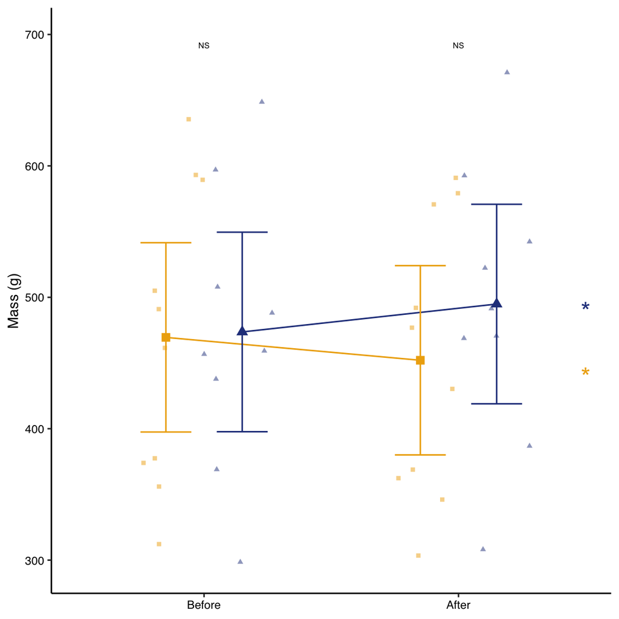

```r
ggplot() +
  geom_point(
    data = tmt_befaft_mass_only,
    aes(
    x = tmt_timing,
    y = Mass_g,
    color = Hydration_Trmt,
    shape = Hydration_Trmt
  ),
    size = 1.1,
    alpha = 0.5,
    position = position_jitterdodge(jitter.width = 0.6, dodge.width = 0.6)
  ) +
  geom_line(
    data = mass_lm_time_tmt_CI,
    aes(
      x = tmt_timing, y = estimate,
      group = Hydration_Trmt,
      color = Hydration_Trmt
    ),
    position = position_dodge(width = 0.6)
  ) +
  geom_errorbar(
    data = mass_lm_time_tmt_CI,
    aes(
      x = tmt_timing, y = estimate,
      ymin = conf.low, ymax = conf.high,
      group = Hydration_Trmt,
      color = Hydration_Trmt
    ),
    width = 0.4,
    position = position_dodge(width = 0.6)
  ) +
  geom_point(
    data = mass_lm_time_tmt_CI,
    aes(
      x = tmt_timing, y = estimate,
      group = Hydration_Trmt,
      color = Hydration_Trmt,
      shape = Hydration_Trmt
    ),
    size = 2.5,
    position = position_dodge(width = 0.6)
  ) +

  # prettys
  scale_color_manual(
    values = c("darkgoldenrod2", "royalblue4"),
    labels = c("C" = "Control", "W" = "Hydration"),
    name = NULL
  ) +
  scale_shape_manual(
    values = c(15, 17),
    labels = c("C" = "Control", "W" = "Hydration"),
    name = NULL
  ) +
  labs(
    x = NULL,
    y = "Mass (g)",
    color = "Treatment"
  ) +
  scale_y_continuous(
    limits = c(295, 700),
    breaks = seq(300, 700, by = 100)
  ) +

  theme(legend.position = "none") +

  # statistical labels
  annotate(geom = "text", x = 1, y = 692, label = "NS", size = 2) +
  annotate(geom = "text", x = 2, y = 692, label = "NS", size = 2) +
  #annotate(geom = "text", x = 2, y = 685, label = "*", size = 6) +
  annotate(geom = "text", x = 2.5, y = 440, label = "*", size = 6,
           color = "darkgoldenrod2") +
  annotate(geom = "text", x = 2.5, y = 490, label = "*", size = 6,
           color = "royalblue4") -> mother_mass_all # save

mother_mass_all
```

## osmol raw

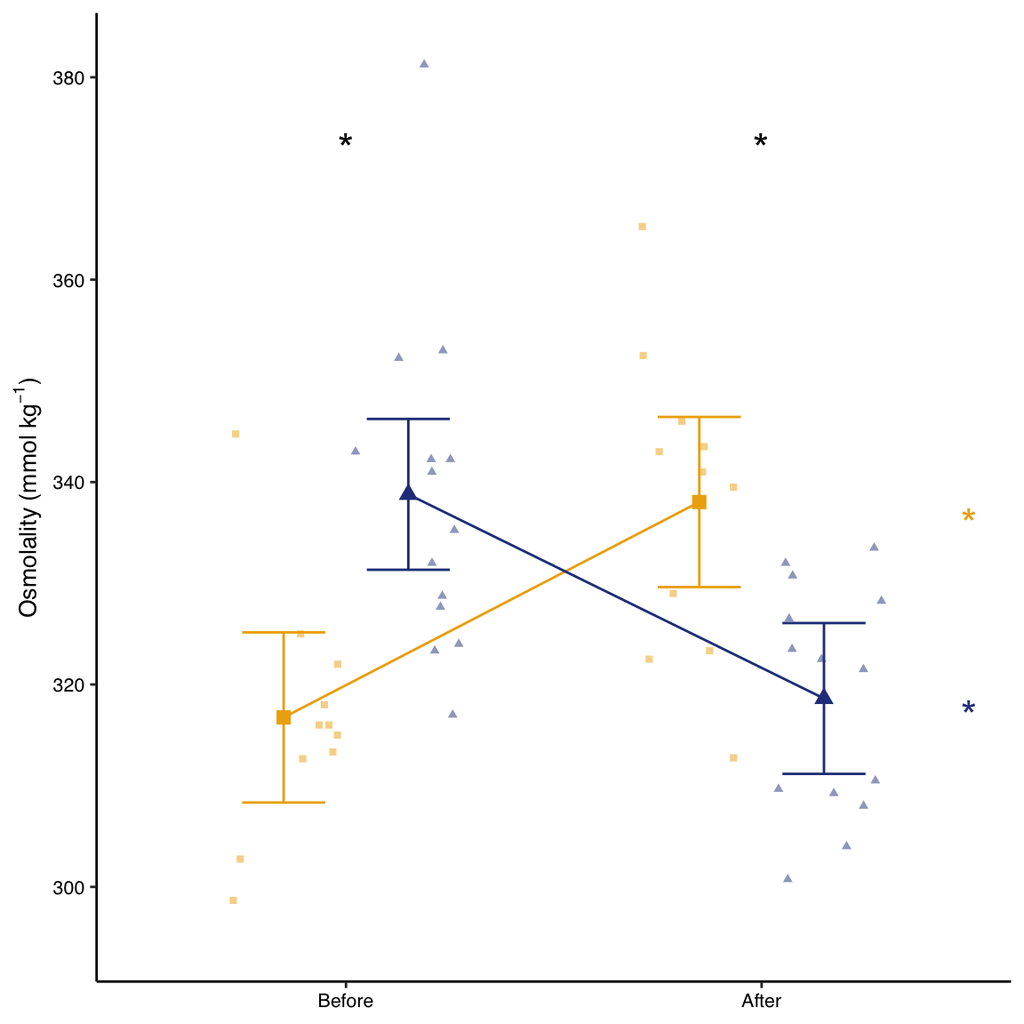

```r
ggplot() +
  geom_point(
    data = tmt_befaft,
    aes(
    x = tmt_timing,
    y = Plasma_Osmol_Rep_mean,
    color = Hydration_Trmt,
    shape = Hydration_Trmt
  ),
    size = 1.1,
    alpha = 0.5,
    position = position_jitterdodge(jitter.width = 0.6, dodge.width = 0.6)
  ) +
  geom_line(
    data = osml_lm_time_tmt_CI,
    aes(
      x = tmt_timing, y = estimate,
      group = Hydration_Trmt,
      color = Hydration_Trmt
    ),
    position = position_dodge(width = 0.6)
  ) +
  geom_errorbar(
    data = osml_lm_time_tmt_CI,
    aes(
      x = tmt_timing, y = estimate,
      ymin = conf.low, ymax = conf.high,
      group = Hydration_Trmt,
      color = Hydration_Trmt
    ),
    width = 0.4,
    position = position_dodge(width = 0.6)
  ) +
  geom_point(
    data = osml_lm_time_tmt_CI,
    aes(
      x = tmt_timing, y = estimate,
      group = Hydration_Trmt,
      color = Hydration_Trmt,
      shape = Hydration_Trmt
    ),
    size = 2.5,
    position = position_dodge(width = 0.6)
  ) +

  # prettys
  scale_color_manual(
    values = c("darkgoldenrod2", "royalblue4"),
    labels = c("C" = "Control", "W" = "Hydration"),
    name = NULL
  ) +
  scale_shape_manual(
    values = c(15, 17),
    labels = c("C" = "Control", "W" = "Hydration"),
    name = NULL
  ) +
  labs(
    x = NULL,
    y = expression('Osmolality (mmol '*kg^-1*')'),
    color = "Treatment"
  ) +
  scale_y_continuous(
    limits = c(295, 382),
    breaks = seq(280, 380, by = 20)
  ) +

  theme(legend.position = "none") +

  # statistical labels
  annotate(geom = "text", x = 1, y = 373, label = "*", size = 6) +
  annotate(geom = "text", x = 2, y = 373, label = "*", size = 6) +
  annotate(geom = "text", x = 2.5, y = 336, label = "*", size = 6,
           color = "darkgoldenrod2") +
  annotate(geom = "text", x = 2.5, y = 317, label = "*", size = 6,
           color = "royalblue4") -> mother_osmolality_all

mother_osmolality_all
```

## cewl raw

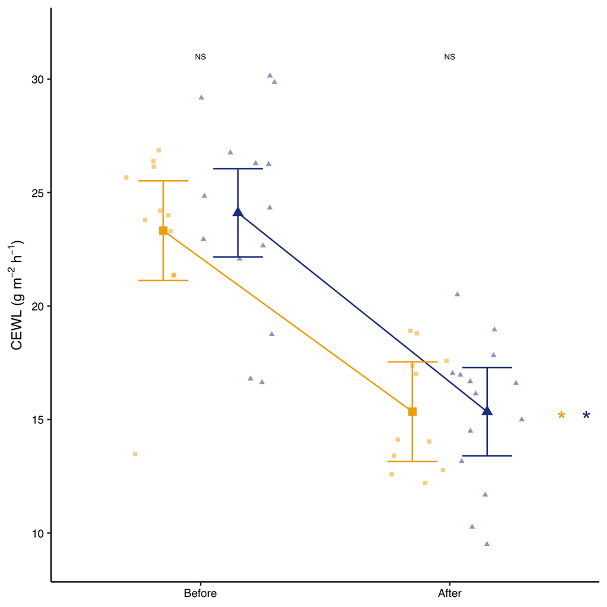

```r
ggplot() +
  geom_point(
    data = tmt_befaft,
    aes(
    x = tmt_timing,
    y = CEWL_g_m2h,
    color = Hydration_Trmt,
    shape = Hydration_Trmt
  ),
    size = 1.1,
    alpha = 0.5,
    position = position_jitterdodge(jitter.width = 0.6, dodge.width = 0.6)
  ) +
  geom_line(
    data = cewl_lm_time_tmt_CI,
    aes(
      x = tmt_timing, y = estimate,
      group = Hydration_Trmt,
      color = Hydration_Trmt
    ),
    position = position_dodge(width = 0.6)
  ) +
  geom_errorbar(
    data = cewl_lm_time_tmt_CI,
    aes(
      x = tmt_timing, y = estimate,
      ymin = conf.low, ymax = conf.high,
      group = Hydration_Trmt,
      color = Hydration_Trmt
    ),
    width = 0.4,
    position = position_dodge(width = 0.6)
  ) +
  geom_point(
    data = cewl_lm_time_tmt_CI,
    aes(
      x = tmt_timing, y = estimate,
      group = Hydration_Trmt,
      color = Hydration_Trmt,
      shape = Hydration_Trmt
    ),
    size = 2.5,
    position = position_dodge(width = 0.6)
  ) +

  # prettys
  scale_color_manual(
    values = c("darkgoldenrod2", "royalblue4"),
    labels = c("C" = "Control", "W" = "Hydration"),
    name = NULL
  ) +
  scale_shape_manual(
    values = c(15, 17),
    labels = c("C" = "Control", "W" = "Hydration"),
    name = NULL
  ) +
  labs(
    x = NULL,
    y = expression('CEWL (g '*m^-2*' '*h^-1*')'),
    color = "Treatment"
  ) +
  scale_y_continuous(
    limits = c(9, 32),
    breaks = seq(10, 30, by = 5)
  ) +

  theme(legend.position = "none") +

  # statistical labels
  annotate(geom = "text", x = 1, y = 31, label = "NS", size = 2) +
  annotate(geom = "text", x = 2, y = 31, label = "NS", size = 2) +
  annotate(geom = "text", x = 2.45, y = 15, label = "*", size = 6,
           color = "darkgoldenrod2") +
  annotate(geom = "text", x = 2.55, y = 15, label = "*", size = 6,
           color = "royalblue4") -> mother_cewl_all

mother_cewl_all
```

## change in mass

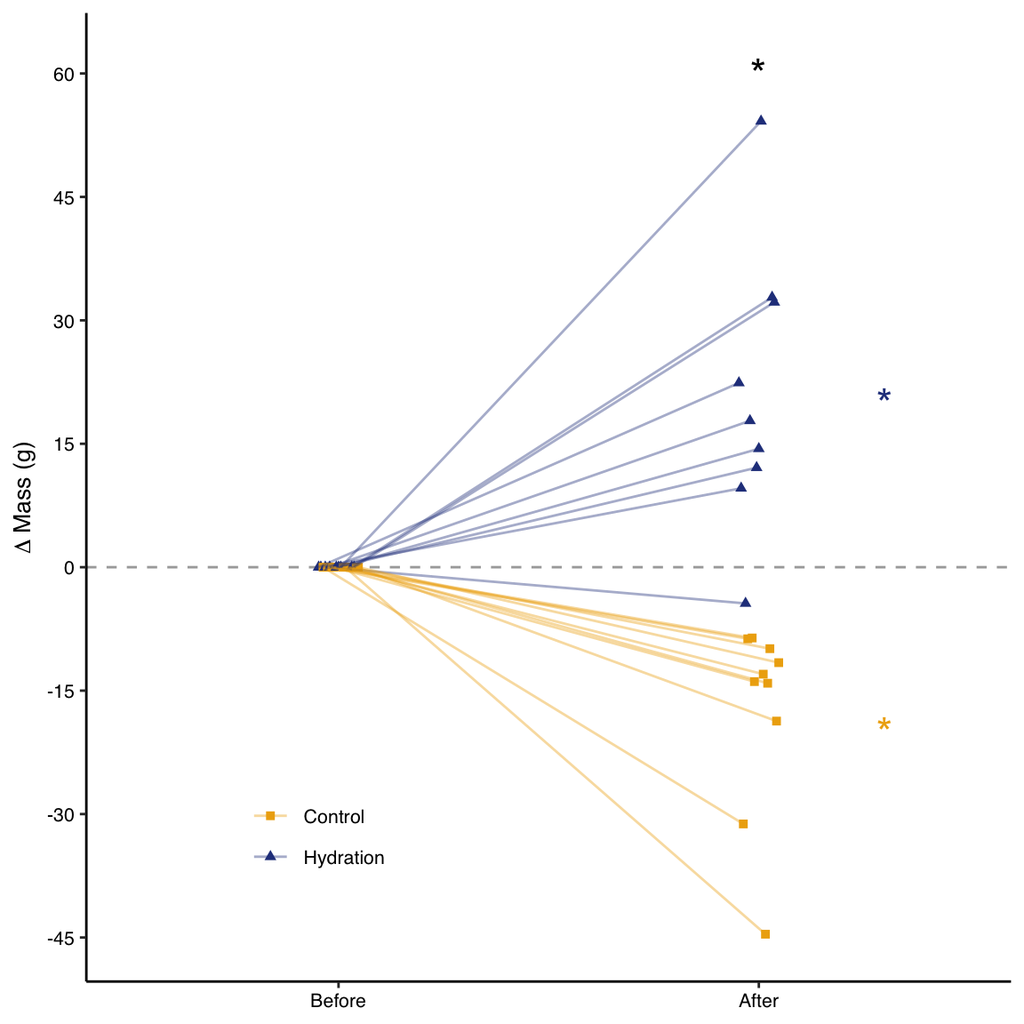

```r
ggplot(
  data = deltas_befaft_mass_only,
  aes(
    x = tmt_timing,
    y = delta_mass,
    group = Indiv_ID,
    color = Hydration_Trmt,
    shape = Hydration_Trmt
  )) +
  geom_hline(yintercept = 0, linetype = 'dashed', color = "darkgray") +
  geom_point(size = 1.4, position = position_dodge(width = 0.1)) +
  geom_line(alpha = 0.4, position = position_dodge(width = 0.1)) +

  # prettys
  scale_color_manual(
    values = c("darkgoldenrod2", "royalblue4"),
    labels = c("C" = "Control", "W" = "Hydration"),
    name = NULL
  ) +
  scale_shape_manual(
    values = c(15, 17),
    labels = c("C" = "Control", "W" = "Hydration"),
    name = NULL
  ) +
  labs(
    x = NULL,
    y = expression(Delta ~ 'Mass (g)'),
    color = "Treatment"
  ) +
  scale_y_continuous(
    limits = c(-45, 62),
    breaks = c(-45, -30, -15, 0, 15, 30, 45, 60)
  ) +

  theme(legend.position = "inside",
        legend.position.inside = c(0.25, 0.15),
        legend.background = element_blank()) +

  # labels
  annotate(geom = "text", x = 2.3, y = 20, label = "*", size = 6,
           color = "royalblue4") +
  annotate(geom = "text", x = 2.3, y = -20, label = "*", size = 6,
           color = "darkgoldenrod2") +
  annotate(geom = "text", x = 2, y = 60, label = "*",
           size = 6) -> mother_change_mass
mother_change_mass
```

## change in osmol

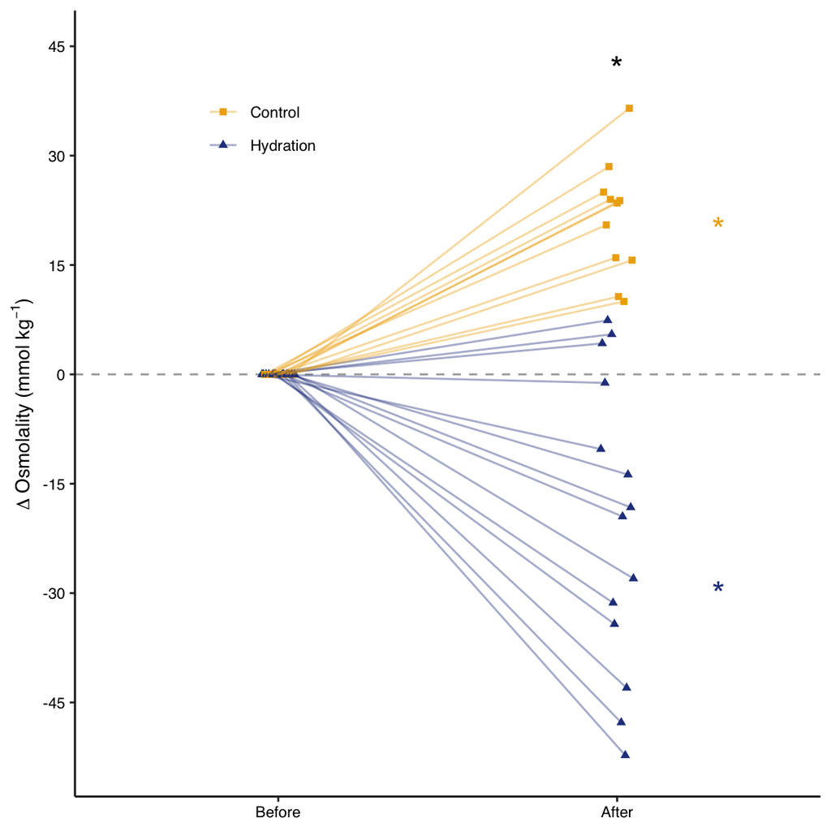

```r
ggplot(
  data = deltas_befaft,
  aes(
    x = tmt_timing,
    y = delta_osml,
    group = Indiv_ID,
    color = Hydration_Trmt,
    shape = Hydration_Trmt
  )) +
  geom_hline(yintercept = 0, linetype = 'dashed', color = "darkgray") +
  geom_point(size = 1.4, position = position_dodge(width = 0.1)) +
  geom_line(alpha = 0.4, position = position_dodge(width = 0.1)) +

  # prettys
  scale_color_manual(
    values = c("darkgoldenrod2", "royalblue4"),
    labels = c("C" = "Control", "W" = "Hydration"),
    name = NULL
  ) +
  scale_shape_manual(
    values = c(15, 17),
    labels = c("C" = "Control", "W" = "Hydration"),
    name = NULL
  ) +
  labs(
    x = NULL,
    y = expression(Delta ~ 'Osmolality (mmol '*kg^-1*')'),
    color = "Treatment"
  ) +
  scale_y_continuous(
    limits = c(-53, 45),
    breaks = c(-45, -30, -15, 0, 15, 30, 45)
  ) +

  theme(legend.position = "inside",
        legend.position.inside = c(0.25, 0.85),
        legend.background = element_blank()) +

  # labels
  annotate(geom = "text", x = 2.3, y = -30, label = "*", size = 6,
           color = "royalblue4") +
  annotate(geom = "text", x = 2.3, y = 20, label = "*", size = 6,
           color = "darkgoldenrod2") +
  annotate(geom = "text", x = 2, y = 42, label = "*",
           size = 6) -> mother_change_osml
mother_change_osml
```

## change in cewl

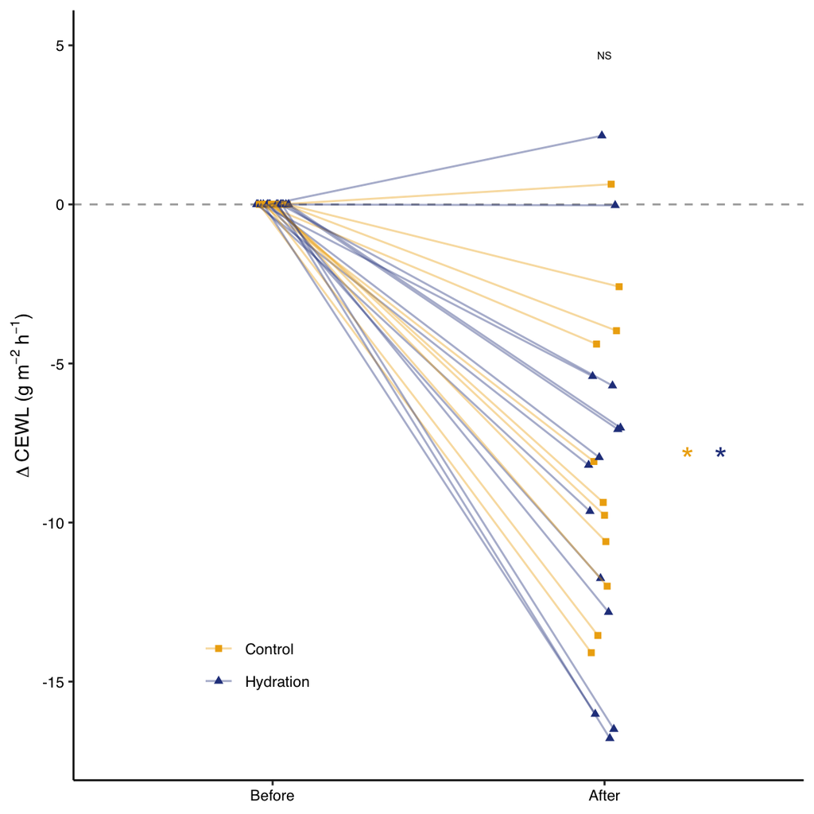

```r
ggplot(
  data = deltas_befaft,
  aes(
    x = tmt_timing,
    y = delta_CEWL,
    group = Indiv_ID,
    color = Hydration_Trmt,
    shape = Hydration_Trmt
  )) +
  geom_hline(yintercept = 0, linetype = 'dashed', color = "darkgray") +
  geom_point(size = 1.4, position = position_dodge(width = 0.1)) +
  geom_line(alpha = 0.4, position = position_dodge(width = 0.1)) +

  # prettys
  scale_color_manual(
    values = c("darkgoldenrod2", "royalblue4"),
    labels = c("C" = "Control", "W" = "Hydration"),
    name = NULL
  ) +
  scale_shape_manual(
    values = c(15, 17),
    labels = c("C" = "Control", "W" = "Hydration"),
    name = NULL
  ) +
  labs(
    x = NULL,
    y = expression(Delta ~ 'CEWL (g '*m^-2*' '*h^-1*')'),
    color = "Treatment"
  ) +
  scale_y_continuous(
    limits = c(-17, 5),
    breaks = c(-15, -10, -5, 0, 5, 10)
  ) +

  theme(legend.position = "inside",
        legend.position.inside = c(0.25, 0.15),
        legend.background = element_blank()) +

  # labels
  annotate(geom = "text", x = 2.25, y = -8, label = "*", size = 6,
           color = "darkgoldenrod2") +
  annotate(geom = "text", x = 2.35, y = -8, label = "*", size = 6,
           color = "royalblue4") +
  annotate(geom = "text", x = 2, y = 4.7, label = "NS",
           size = 2) -> mother_change_cewl
mother_change_cewl
```

## arrange

```r
ggarrange(
  mother_mass_all, mother_change_mass,
  mother_osmolality_all, mother_change_osml,
  mother_cewl_all, mother_change_cewl,
  nrow = 3,
  ncol = 2,
  labels = c("A", "B", "C", "D", "E", "F"),
  align = "hv"
) -> mother_tmt_effects

ggsave(
  filename = "Fig1_mother_tmt_effects.pdf",
  plot = mother_tmt_effects,
  path = "./results_figures",
  device = "pdf",
  dpi = 600,
  units = "mm",
  width = 160,
  height = 180
)
ggsave(
  filename = "Fig1_mother_tmt_effects.tiff",
  plot = mother_tmt_effects,
  path = "./results_figures",
  device = "tiff",
  dpi = 600,
  units = "mm",
  width = 160,
  height = 180
)
```